# RNA-seq

Francisco Javier Polo Martinez

2023-05-10

Instalar y cargar paquetes generales

```r
# install.packages(pacman)
library(pacman)

pacman::p_load(
rio,            # Importaci6n de fichero
here,           # Localizador de archives
tidyverse,      # gesti6n de datos + graficos ggplot2
imputeTS,       # para rellenar valores perdidos
R.utils,        # Utilidades de R
downloadthis,   # Descargar archivos en HTML
readxl,         # Leer archivos xl
data.table,     # Manipulacion
dplyr,          # Manipulacion
scales,         # Escalar datos
ggplot2,        # Graficos
stringi,        # Manipulacion de strings
stringr,        # Manipulacion de strings
knitr,          # RMardown
kableExtra,     # Tablas
ggpubr,         # Charts elaborated
ggeasy,         # Graficos faciles gglot
lubridate,      # Funciones para trabajar con fechas-horas
plotly,         # Graficos
tmaptools,      # para obtener geocoordenadas (lon/lat) por nombre de lugares
sf,
magick,
caRtociudad,    # acceder a la informacion de las APIs de cartociudda
stringr,        # manipulacion de string
CatastRo,       # acceso al API de catastro
mapSpain,       # objetos sf administrivos de espana
magrittr,       # operadores
remotes,        # instalar paquetes de repositorios remotos o locales
maps,           # dibujar mapas geograficos
htmltools,      # herramientas para HTML
leaflet,        # mapas
htmlwidgets,
remotes,
rgdal,
sp,
sf,
knitr,
htmlTable,
rJava,
flextable,
devtools,
mdsr,
tidygeocoder,
reticulate
)
```

```r
# BiocManager::install("DESeq2", force = TRUE)
library(Rbowtie2) |> suppressPackageStartupMessages()     # <- align FASTQ files
library(Rsamtools) |> suppressPackageStartupMessages()    # <- manipulate SAM files
library(tidyverse) |> suppressPackageStartupMessages()
library(R.utils) |> suppressPackageStartupMessages()
library(Rsubread) |> suppressPackageStartupMessages()     # <- quantify alignments
library(ShortRead) |> suppressPackageStartupMessages()
library(DESeq2) |> suppressPackageStartupMessages()       # <- differential gene expression
```

**ARCHIVOS NECESARIOS**

```r
knitr::include_graphics("flujo.jpg")
```

[output not shown]

leemos desde el directorio de trabajo la ruta completa de los archivos fastq, con $, decimos que acaben el fastq

```r
fastq.files <- list.files(path = "C:/Users/polo/OneDrive/ZZZ/00GENESPECTRUM/00TALLER/SESION06", pattern = ".fastq$", full.names = TRUE)
fastq.files
```

```
 [1] "C:/Users/polo/OneDrive/ZZZ/00GENESPECTRUM/00TALLER/SESION06/SRR1552444.fastq"
 [2] "C:/Users/polo/OneDrive/ZZZ/00GENESPECTRUM/00TALLER/SESION06/SRR1552445.fastq"
 [3] "C:/Users/polo/OneDrive/ZZZ/00GENESPECTRUM/00TALLER/SESION06/SRR1552446.fastq"
 [4] "C:/Users/polo/OneDrive/ZZZ/00GENESPECTRUM/00TALLER/SESION06/SRR1552447.fastq"
 [5] "C:/Users/polo/OneDrive/ZZZ/00GENESPECTRUM/00TALLER/SESION06/SRR1552448.fastq"
 [6] "C:/Users/polo/OneDrive/ZZZ/00GENESPECTRUM/00TALLER/SESION06/SRR1552449.fastq"
 [7] "C:/Users/polo/OneDrive/ZZZ/00GENESPECTRUM/00TALLER/SESION06/SRR1552450.fastq"
 [8] "C:/Users/polo/OneDrive/ZZZ/00GENESPECTRUM/00TALLER/SESION06/SRR1552451.fastq"
 [9] "C:/Users/polo/OneDrive/ZZZ/00GENESPECTRUM/00TALLER/SESION06/SRR1552452.fastq"
[10] "C:/Users/polo/OneDrive/ZZZ/00GENESPECTRUM/00TALLER/SESION06/SRR1552453.fastq"
[11] "C:/Users/polo/OneDrive/ZZZ/00GENESPECTRUM/00TALLER/SESION06/SRR1552454.fastq"
[12] "C:/Users/polo/OneDrive/ZZZ/00GENESPECTRUM/00TALLER/SESION06/SRR1552455.fastq"
```

```r
pwd <- paste0(dirname(getwd()), "/SESION06")
print(pwd)
```

```
[1] "C:/Users/polo/OneDrive/ZZZ/00GENESPECTRUM/00TALLER/SESION06"
```

```r
fq <- ShortRead::readFastq(dirPath = pwd, pattern = "*.fastq$", full.names = T)
fq
```

```
class: ShortReadQ
length: 120000 reads; width: 100 cycles
```

```r
head(ShortRead::sread(fq), 10)
```

```
DNAStringSet object of length 10:
     width seq
 [1]   100 TGAATTTTAAGACAAATATTCTACACGGCATATTGCACAGGATGGATGGTTAAAAAAAAAGAAATAAAAAAAGAAAGGAAAAAAAAAAGAGTTTTAAAAC
 [2]   100 CCAAGGCCTACCGGGAGGACAAGAGCGAGCCGAAGGCCTACAGGCGGCGGCAGCGGTCCCTGAGCCCGCTGGGAGGCCGGGACGAAAGCCCGGTGTCCCA
 [3]   100 TCAGCTCTGTGCTGTGCTTGGTGTGGGCGCCCAGTTCCTGGCCCTTGGCACTGGCATTATTGTCATGGCGTTGCTTGGCATGTTCAACGTGCACCGTCAC
 [4]   100 TCTACATCCACCAGTTCTGTCTCATAGATCTCAGCGATGGAGATGTGGTGCTTGGCTGCGATTGTGAATCTGCCCATGTCTGTATAGATCTCAATTGCTC
 [5]   100 GCCTCAACAGCCTGGGCTCCTTCTTCTGCCTCTGTGCACCCGGCTTTGCTAGTGCTGAGGGGGGCACCAGATGCCAGGATGTTGATGAATGTGCAGCCAC
 [6]   100 GCGAGGTTCTGCAGACCCCGAAGAAGAAAGTGTTCTGTACTCCAACCGTGCAGCGTGCTACTTGAAGGATGGGAACTGCACAGATTGCATCAAAGATTGC
 [7]   100 GGAGAAGGCACATGTGAAGGTGTTTCTTTTTCCCCTTTAGTACAGTTCAATATGTCTAATGCACAGTAACAGTGTTGTTATTGAGTTAACTAGTAAATGG
 [8]   100 CAACAATTGGTCTCCTCCAGTGCAAAGCAATGAAACATCAAATGGTTATTTCTTAGAGAGATCACACAGCGCTAGGATGACACTTGCAAAAGCTTGTGGA
 [9]   100 CCACTGTTCGGTCTGGTCCAGGTAGTGTACCGCAATGACTGTTGGTGTCATGCCAATCATGTTCTGTTCCCCACAGCCTGCGGGGGTCACGATCAGGTGT
[10]   100 GTAACCTGAAGTTCTGACTCTCAGTTTAACCTGTTGACAGCCAATCTGAACTTGTGTTTCTTGCCAAAGGTATTCCCATGAGCCTCCTGGGTGTGGGGGT
```

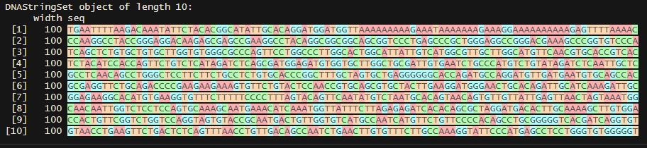

```r
knitr::include_graphics("C:/Users/polo/OneDrive/ZZZ/00GENESPECTRUM/00TALLER/SESION07/Captura.jpg")
```

```r
head(Biostrings::detail(fq), 10)
```

```
class:  ShortReadQ

sread:
DNAStringSet object of length 120000:
         width seq
     [1]   100 TGAATTTTAAGACAAATATTCTACACGGCATATTGCACAGGATGGATGGTTAAAAAAAAAGAAATAAAAAAAGAAAGGAAAAAAAAAAGAGTTTTAAAAC
     [2]   100 CCAAGGCCTACCGGGAGGACAAGAGCGAGCCGAAGGCCTACAGGCGGCGGCAGCGGTCCCTGAGCCCGCTGGGAGGCCGGGACGAAAGCCCGGTGTCCCA
     [3]   100 TCAGCTCTGTGCTGTGCTTGGTGTGGGCGCCCAGTTCCTGGCCCTTGGCACTGGCATTATTGTCATGGCGTTGCTTGGCATGTTCAACGTGCACCGTCAC
     [4]   100 TCTACATCCACCAGTTCTGTCTCATAGATCTCAGCGATGGAGATGTGGTGCTTGGCTGCGATTGTGAATCTGCCCATGTCTGTATAGATCTCAATTGCTC
     [5]   100 GCCTCAACAGCCTGGGCTCCTTCTTCTGCCTCTGTGCACCCGGCTTTGCTAGTGCTGAGGGGGGCACCAGATGCCAGGATGTTGATGAATGTGCAGCCAC
     ...   ... ...
[119996]   100 TGACTTCCACGTGTTCTGATTAGTATGCCTGACTTCCATGTGTCCTAATTAGGATGCCTGACTTCCATGAACCCATTTCAATGGTGTAGCTGACGCTGTG
[119997]   100 GATCAATTAAAAGAACTTACCAAGCAGTATGAAAAGTCTGAAAATGATTTGAAGGCACTACAAAGTGTTGGACAGATTGTAGGTGAAGTGCTAAAACAGT
[119998]   100 GGGAAATGCAGAAATGACTGCAGTGCAGCAGTAATTATGGTGCACTTTTTTCGCTATTTAAGTTGGATATTTCTCTACATTCCTGAAACAATTTTTAGGT
[119999]   100 GGCCTTTTCACTGTAAACTAGAGGACGGGGGCAGGCAGCACTGGGAACTTAGACATCCAAGCTGGTGTTCAGGGACTGCTCATGGCCCCAGCCCCCGTGC
[120000]   100 CTTCCCTACACCTCAAAGAAGAGACTCCTTTGCATGTCTGGAGACAGTAGGGGGTGGTAAACTAAAGGGAAGTTGAGAGTGTATACTGCTGGGAGTGGGG

id:
BStringSet object of length 120000:
         width seq
     [1]    61 SRR1552444.12376817 DCV4KXP1:223:C2CTUACXX:1:1312:2565:9444/1
     [2]    62 SRR1552444.11626500 DCV4KXP1:223:C2CTUACXX:1:1309:6582:58767/1
     [3]    61 SRR1552444.12982779 DCV4KXP1:223:C2CTUACXX:1:1314:3335:4943/1
     [4]    60 SRR1552444.1331889 DCV4KXP1:223:C2CTUACXX:1:1106:5447:2665/1
     [5]    62 SRR1552444.6537911 DCV4KXP1:223:C2CTUACXX:1:1207:11747:90604/1
     ...   ... ...
[119996]    63 SRR1552455.10800309 DCV4KXP1:223:C2CTUACXX:2:1310:19772:39488/1
[119997]    62 SRR1552455.16070238 DCV4KXP1:223:C2CTUACXX:2:2113:8699:75474/1
[119998]    62 SRR1552455.20343962 DCV4KXP1:223:C2CTUACXX:2:2213:3057:99387/1
[119999]    62 SRR1552455.1329719 DCV4KXP1:223:C2CTUACXX:2:1106:13735:53837/1
[120000]    63 SRR1552455.14779493 DCV4KXP1:223:C2CTUACXX:2:2109:12729:14893/1
class: FastqQuality
quality:
BStringSet object of length 120000:
         width seq
     [1]   100 CCCFFFFFHHGHHJJJJJJJJIJJJJJJIJFIJIJJIJJJJIIJJJJJIIIJIJJJJIHDDDEDDDDDDDDDDDDDDDDDDDDDDDDDDDDCACDDDDDD
     [2]   100 CCCFFFFFHHHHHJJJJJJJJJJJJJJJJIJJJJJJJJJIHFHHHFDDDDDDDDDD<<DDDDDDDDDDDDDDDDDBDDDDDDDDDDDBCDDDDDDDDDDD
     [3]   100 1=+4=DDAB?D?FIHEGGHBE3<A?CGFFDH>GHGFGGE@>>BFCHGIDIGA@@ECEHBEHHC?CADCB6339;CCC@:@CB3@@C@@B?ABBC><8<?B
     [4]   100 CCCFFFFFHHHHHJJJJJJJJJJJJJJJJJJJJJJJJJIJJJIJJIIJFIIJJJIJIJJJHJJJJHHHHGHHFFFFFEEEEEEFEEEDEDEDDDDEDDDD
     [5]   100 CCCFFFFFHHHHHJJJJJJJJJJJJJJJJJJJJIIJJIJJJJIJJJJJJJJIIIJJJIJJJHFDDDDDDBDDDDDDDDDDDDDDDDDEDEDDEDEDDDDD
     ...   ... ...
[119996]   100 CCCFFFFFHHHHHIIIJJIIJGIEGIIJJJJJJJJJJJJJJJJJJJJIJGIHHGHIJIJJJJJJJJIJJIJIJJJHIIJGFHHFHFFFFFFEEECDDDDD
[119997]   100 @B+ADDFFHHHHHJJJJJJJIJJJJJJIJJJJJJJJGHIJJJJJJJJJJJJJHJJIJIIJJIIIJHHIJJIJIIJHHHHHHHFFFFFEEEEEEEDDDBDC
[119998]   100 CCCFFFFFGHHHHJIJJJJJJIHEHIJJJIJHIJJJJIJJFHHJIJIJJJJJIJJJJJJJJJGHJJJIIHHHHHHHFEFFFFFECCCEEDDDDDDDDDDC
[119999]   100 CCCFFFFFHHHHHIIJIJJIGFHIGGIJJJJIJJJIJHHFHFFFFFDDEEEDDDDDDDC>C?CDDCCBBDEDDDD@BBDDDDDDDDDDDDDDDDDDDDDD
[120000]   100 CCCFFFFFHHHHFJJIIIIIIGIJJIJJJJIIJHIGGIIIIEIIIJJFIHJJJJAEEDFFFFEEEEEDDBBDCCDCCDD>CACDDEDEDDDDDAB8ADDB
```

```
BStringSet object of length 10:
     width seq
 [1]   100 CCCFFFFFHHGHHJJJJJJJJIJJJJJJIJFIJIJJIJJJJIIJJJJJIIIJIJJJJIHDDDEDDDDDDDDDDDDDDDDDDDDDDDDDDDDCACDDDDDD
 [2]   100 CCCFFFFFHHHHHJJJJJJJJJJJJJJJJIJJJJJJJJJIHFHHHFDDDDDDDDDD<<DDDDDDDDDDDDDDDDDBDDDDDDDDDDDBCDDDDDDDDDDD
 [3]   100 1=+4=DDAB?D?FIHEGGHBE3<A?CGFFDH>GHGFGGE@>>BFCHGIDIGA@@ECEHBEHHC?CADCB6339;CCC@:@CB3@@C@@B?ABBC><8<?B
 [4]   100 CCCFFFFFHHHHHJJJJJJJJJJJJJJJJJJJJJJJJJIJJJIJJIIJFIIJJJIJIJJJHJJJJHHHHGHHFFFFFEEEEEEFEEEDEDEDDDDEDDDD
 [5]   100 CCCFFFFFHHHHHJJJJJJJJJJJJJJJJJJJJIIJJIJJJJIJJJJJJJJIIIJJJIJJJHFDDDDDDBDDDDDDDDDDDDDDDDDEDEDDEDEDDDDD
 [6]   100 @CCFDFDEHGHHHJIJJJJJJJJJJJIJGGBGIGIJJEGGHIGI@FFEFHEEGGGHAEDFFFEEEEEDEDDDDCDBDDDCDCDDDDDDDEDDDDCDDDDD
 [7]   100 @C@FFFDDDGHHHIEHGHIG<CCFIHHHIIIIGGGIIIIEDEHGEFGGIGHIIAFGIIIICFFGIIDHGICGFFHCAHIHHHFFEEFFFFFFBCEDCCDC
 [8]   100 CCCFFFFFHHHHHJJJIJJJHJJJJJJIJJJJJJJJJJJJJJJJJGHIJJJJJIIIJIJJJIJJJJJJJIJHHHFFFFEDEDEEDDDDDDDDDDDDDD<C
 [9]   100 ?;;?BDDD?FAHHD@@GAC@?BAFBFECEH<D8D@GGAFH@HBD9//.8CCFE3=FGG@AE@EED>CC>;?DEECC;?C?B:?;B5052@@<?A######
[10]   100 CCCFFFFFHHHHHJJJJJJJJJJJJJJJJJJJJIJIJJJJJIJIJJJJJJJJJJIJJJJJJJJJJJIJJJGIIIJIJJHHHHHFFFFFEDD;?@DDDDD5
```

```r
ShortRead::sread(fq)[256]
```

```
DNAStringSet object of length 1:
    width seq
[1]   100 CATCAGTCTAATCCCCAGTCACTCCATCCAAGTGTCCCTGTGGGGTGTGGCTTTCTCTGTTGTAATTAGCATGTAGTACCTATCTCCTCCTCCCTGTTTC
```

```r
x <- strsplit(x = as.character(ShortRead::sread(fq)[256]),"")
table(x)
```

```
x
 A  C  G  T
16 31 18 35
```

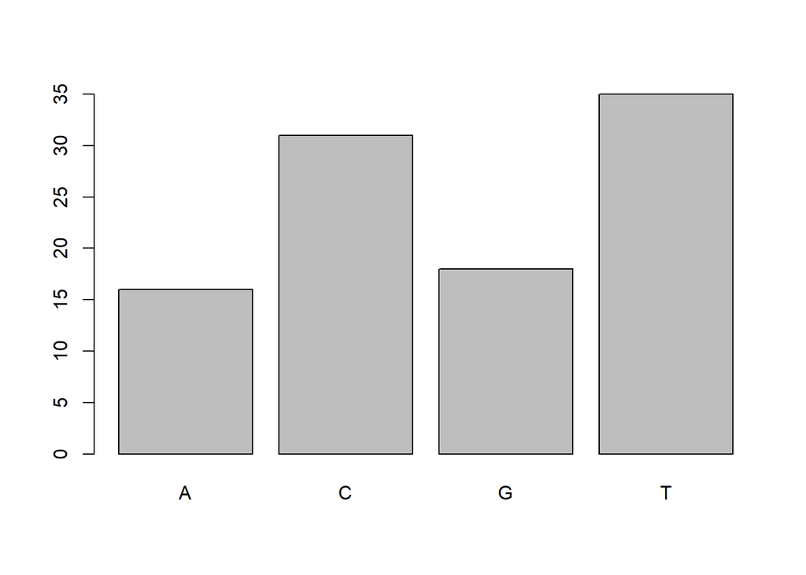

```r
barplot(table(x))
```

```r
Biostrings::alphabetFrequency(x = ShortRead::sread(fq),
                              baseOnly = TRUE,
                              collapse = TRUE)
```

```
      A       C       G       T   other
3016229 3001728 2961237 3020158     648
```

Tambien podemos observar la frecuencia absoluta de nucleótidos de todas las secuencias en cada ciclo con la función ShortRead::alphabetByCycle. Para verlo de una forma mas amigable, podemos graficar estos datos usando la función matplot()

```r
head(ShortRead::alphabetByCycle(ShortRead::sread(fq)))
```

```
        cycle
alphabet  [,1]  [,2]  [,3]  [,4]  [,5]  [,6]  [,7]  [,8]  [,9] [,10] [,11] [,12] [,13] [,14] [,15] [,16] [,17] [,18] [,19] [,20] [,21] [,22] [,23]
       A 15824 25027 28485 37653 37749 39859 19485 24924 24336 41736 28788 26238 29596 29278 29742 29642 30128 30470 29999 29862 30305 30115 30499
       C 56259 26225 31775 28168 23874 27384 28866 36571 33350 23508 34291 33399 28977 29904 30204 30244 29967 29916 30257 29949 29864 29917 29082
       G 32293 26459 30592 31361 34353 27018 23712 25233 26134 28373 33790 28512 28072 28602 29193 29996 30110 29873 29961 30152 29483 30001 30047
       T 15387 42289 29147 22805 24023 25739 47937 33272 36180 26383 23131 31851 33355 32216 30861 30118 29795 29741 29783 30037 30347 29967 30372
       M     0     0     0     0     0     0     0     0     0     0     0     0     0     0     0     0     0     0     0     0     0     0     0
       R     0     0     0     0     0     0     0     0     0     0     0     0     0     0     0     0     0     0     0     0     0     0     0
        cycle
alphabet [,24] [,25] [,26] [,27] [,28] [,29] [,30] [,31] [,32] [,33] [,34] [,35] [,36] [,37] [,38] [,39] [,40] [,41] [,42] [,43] [,44] [,45] [,46]
       A 30559 30175 30420 30215 30258 30496 29969 30414 30530 30194 29979 30151 30144 29789 30427 30369 30415 30606 30329 29967 30329 29941 30262
       C 29544 29980 29744 29974 30014 29966 29940 30079 29709 29629 30158 29494 30094 30256 29294 29760 30052 29461 29626 30063 29663 29926 30145
       G 29291 30136 29635 29597 29579 29711 29729 29460 29416 29623 30050 30157 29706 29941 30033 29607 29684 29784 29603 29880 29633 29588 29696
       T 30606 29709 30197 30214 30149 29827 30362 30047 30345 30554 29813 30198 30050 30013 30246 30264 29849 30149 30442 30090 30375 30545 29897
       M     0     0     0     0     0     0     0     0     0     0     0     0     0     0     0     0     0     0     0     0     0     0     0
       R     0     0     0     0     0     0     0     0     0     0     0     0     0     0     0     0     0     0     0     0     0     0     0
        cycle
alphabet [,47] [,48] [,49] [,50] [,51] [,52] [,53] [,54] [,55] [,56] [,57] [,58] [,59] [,60] [,61] [,62] [,63] [,64] [,65] [,66] [,67] [,68] [,69]
       A 30472 30206 30008 30247 30118 30234 30493 30222 29937 30404 30370 30437 30542 30158 30055 30561 30369 29976 30392 30555 30040 30415 30238
       C 29762 29861 30111 29839 29835 29755 29558 29705 30216 29725 29990 29807 29505 30196 29858 29794 29849 29834 29451 29627 30092 29537 29649
       G 29814 29362 29578 29894 29689 29535 29676 29770 29502 29644 29311 29872 30036 29399 29745 29361 29196 29902 30266 29656 29873 29599 29136
       T 29949 30562 30301 30017 30354 30473 30267 30302 30345 30226 30329 29884 29917 30247 30333 30284 30586 30288 29891 30162 29995 30449 30977
       M     0     0     0     0     0     0     0     0     0     0     0     0     0     0     0     0     0     0     0     0     0     0     0
       R     0     0     0     0     0     0     0     0     0     0     0     0     0     0     0     0     0     0     0     0     0     0     0
        cycle
alphabet [,70] [,71] [,72] [,73] [,74] [,75] [,76] [,77] [,78] [,79] [,80] [,81] [,82] [,83] [,84] [,85] [,86] [,87] [,88] [,89] [,90] [,91] [,92]
       A 30333 30801 30416 30346 30741 30523 30179 30307 29914 29942 30134 30632 30402 30618 30395 30216 30499 30418 30561 30787 30843 30183 30627
       C 29860 29456 29565 29606 29159 29564 30039 29490 29945 29877 29548 29856 29669 29622 29451 29342 29482 29984 30020 29378 29329 29974 29319
       G 29921 29841 29911 29918 29839 29618 29976 29837 29353 29734 29881 29100 29928 29624 29427 30010 29623 29457 29640 29863 29596 29675 30005
       T 29886 29902 30075 30090 30255 30285 29801 30332 30769 30438 30418 30403 30001 30133 30721 30430 30396 30141 29779 29972 30231 30168 30048
       M     0     0     0     0     0     0     0     0     0     0     0     0     0     0     0     0     0     0     0     0     0     0     0
       R     0     0     0     0     0     0     0     0     0     0     0     0     0     0     0     0     0     0     0     0     0     0     0
        cycle
alphabet [,93] [,94] [,95] [,96] [,97] [,98] [,99] [,100]
       A 30757 30337 30615 30730 30378 30558 30617  30293
       C 29496 29739 29058 29312 29815 29494 29577  29624
       G 29541 29670 30244 29674 29831 29779 29776  30270
       T 30203 30251 30080 30281 29976 30080 29992  29806
       M     0     0     0     0     0     0     0      0
       R     0     0     0     0     0     0     0      0
```

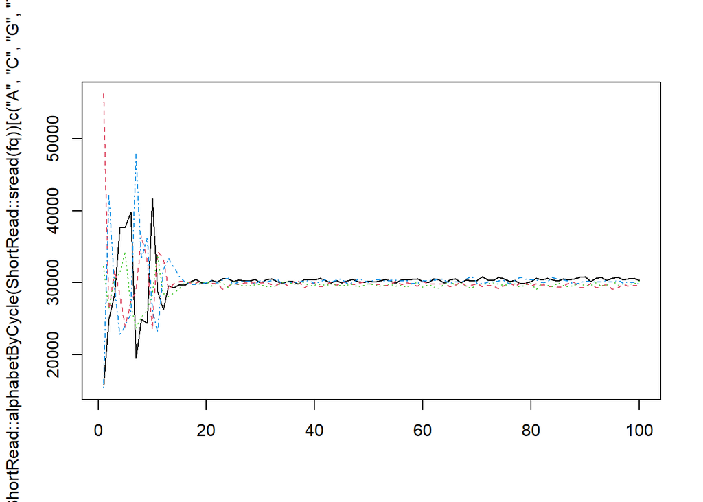

```r
matplot(t(ShortRead::alphabetByCycle(ShortRead::sread(fq))[c("A","C","G","T"),]), type="l")
```

> **ALINEAMIENTO**

**creamos un indice**

este codigo genera los archivos de indice en el directorio de trabajo

```r
start_time <- Sys.time()

chr1_mm10_RD <- buildindex(basename="chr1_mm10",reference="chr1.fa")
```

```
        ==========     _____ _    _ ____  _____  ______          _____
        =====         / ____| |  | |  _ \|  __ \|  ____|   /\   |  __ \
          =====      | (___ | |  | | |_) | |__) | |__     /  \  | |  | |
            ====      \___ \| |  | |  _ <|  _  /|  __|   / /\ \ | |  | |
              ====    ____) | |__| | |_) | | \ \| |____ / ____ \| |__| |
        ==========   |_____/ \____/|____/|_|  \_\______/_/    \_\_____/
       Rsubread 2.12.3

//================================= setting ==================================\\
||                                                                            ||
||                Index name : chr1_mm10                                      ||
||               Index space : base space                                     ||
||               Index split : no-split                                       ||
||          Repeat threshold : 100 repeats                                    ||
||              Gapped index : no                                             ||
||                                                                            ||
||       Free / total memory : 1.1GB / 15.9GB                                 ||
||                                                                            ||
||               Input files : 1 file in total                                ||
||                             o chr1.fa                                      ||
||                                                                            ||
\\============================================================================//

//================================= Running ==================================\\
||                                                                            ||
|| Check the integrity of provided reference sequences ...                    ||
|| No format issues were found                                                ||
|| Scan uninformative subreads in reference sequences ...                     ||
|| 41252 uninformative subreads were found.                                   ||
|| These subreads were excluded from index building.                          ||
|| Estimate the index size...                                                 ||
||    8%,   0 mins elapsed, rate=793.5k bps/s                                 ||
||   16%,   0 mins elapsed, rate=826.7k bps/s                                 ||
||   24%,   1 mins elapsed, rate=780.0k bps/s                                 ||
||   33%,   1 mins elapsed, rate=812.6k bps/s                                 ||
||   41%,   1 mins elapsed, rate=822.3k bps/s                                 ||
||   49%,   1 mins elapsed, rate=834.5k bps/s                                 ||
||   58%,   2 mins elapsed, rate=848.8k bps/s                                 ||
||   66%,   2 mins elapsed, rate=846.2k bps/s                                 ||
||   74%,   2 mins elapsed, rate=859.1k bps/s                                 ||
```

[output cut: 21 more lines]

```
||  [ 10.0% finished ]                                                        ||
||  [ 20.0% finished ]                                                        ||
||  [ 30.0% finished ]                                                        ||
||  [ 40.0% finished ]                                                        ||
||  [ 50.0% finished ]                                                        ||
||  [ 60.0% finished ]                                                        ||
||  [ 70.0% finished ]                                                        ||
||  [ 80.0% finished ]                                                        ||
||  [ 90.0% finished ]                                                        ||
||  [ 100.0% finished ]                                                       ||
||                                                                            ||
||                     Total running time: 18.0 minutes.                      ||
||Index C:\Users\polo\OneDrive\ZZZ\00GENESPECTRUM\00TALLER\SESION06\chr1 ... ||
||                                                                            ||
\\============================================================================//
```

```r
save(chr1_mm10_RD,  file = "chr1_mm10_RD.RData")

end_time <- Sys.time()
tiempo_total<-end_time - start_time
tiempo_total
```

```
Time difference of 17.98518 mins
```

LO GUARDAMOS EN UN FICHERO .RData

se crean los siguientes archivos

- chr1_mm10.00.b.array
- chr1_mm10.00.b.tab
- chr1_mm10.files
- chr1_mm10.reads
- chr1_mm10.log

Ahora podemos alinear los 12 archivos fastq usando el comando “align” Esto alineará cada una de las 12 muestras una tras otra. Los archivos BAM se guardan en el directorio de trabajo. Para ver cuántos parámetros puede cambiar, pruebe la función:args

- **index**: Especifica la ruta o dirección del archivo de índice que contiene la información del genoma de referencia. En este caso, el archivo de índice se encuentra en “C:/Users/polo/OneDrive/ZZZ/00GENESPECTRUM/00TALLER/SESION06/chr1_mm10”.
- **readfile1**: Especifica el nombre o la ruta del archivo de lectura (por ejemplo, archivos FASTQ) que contiene las secuencias a alinear. Parece que se proporciona una variable llamada fastq.files que contiene el nombre del archivo o los nombres de varios archivos de lectura.
- **sortReadsByCoordinates**: Un valor lógico que indica si los resultados del alineamiento deben ordenarse por coordenadas. Si se establece en TRUE, los resultados se ordenarán por coordenadas.
- **nthreads**: Especifica el número de subprocesos o hilos que se utilizarán para realizar el alineamiento. En este caso, se utilizan 4 hilos.

```r
start_time <- Sys.time()

align(index = "C:/Users/polo/OneDrive/ZZZ/00GENESPECTRUM/00TALLER/SESION06/chr1_mm10", readfile1 = fastq.files, sortReadsByCoordinates = TRUE, nthreads = 4)
```

```
        ==========     _____ _    _ ____  _____  ______          _____
        =====         / ____| |  | |  _ \|  __ \|  ____|   /\   |  __ \
          =====      | (___ | |  | | |_) | |__) | |__     /  \  | |  | |
            ====      \___ \| |  | |  _ <|  _  /|  __|   / /\ \ | |  | |
              ====    ____) | |__| | |_) | | \ \| |____ / ____ \| |__| |
        ==========   |_____/ \____/|____/|_|  \_\______/_/    \_\_____/
       Rsubread 2.12.3

//================================= setting ==================================\\
||                                                                            ||
|| Function      : Read alignment (RNA-Seq)                                   ||
|| Input file    : SRR1552444.fastq                                           ||
|| Output file   : SRR1552444.fastq.subread.BAM (BAM), Sorted                 ||
|| Index name    : chr1_mm10                                                  ||
||                                                                            ||
||                    ------------------------------------                    ||
||                                                                            ||
||                               Threads : 4                                  ||
||                          Phred offset : 33                                 ||
||                             Min votes : 3 / 10                             ||
||                        Max mismatches : 3                                  ||
||                      Max indel length : 5                                  ||
||            Report multi-mapping reads : yes                                ||
|| Max alignments per multi-mapping read : 1                                  ||
||                                                                            ||
\\============================================================================//

//================ Running (19-ago.-2023 19:52:34, pid=4952) =================\\
||                                                                            ||
|| Check the input reads.                                                     ||
|| The input file contains base space reads.                                  ||
|| Initialise the memory objects.                                             ||
|| Estimate the mean read length.                                             ||
|| The range of Phred scores observed in the data is [2,41]                   ||
|| Create the output BAM file.                                                ||
|| Check the index.                                                           ||
|| Init the voting space.                                                     ||
|| Global environment is initialised.                                         ||
|| Load the 1-th index block...                                               ||
|| The index block has been loaded.                                           ||
```

[output cut: 676 more lines]

```

//================================   Summary =================================\\
||                                                                            ||
||                 Total reads : 10000                                        ||
||                      Mapped : 1222 (12,2%)                                 ||
||             Uniquely mapped : 1178                                         ||
||               Multi-mapping : 44                                           ||
||                                                                            ||
||                    Unmapped : 8778                                         ||
||                                                                            ||
||                      Indels : 41                                           ||
||                                                                            ||
||                Running time : 1,3 minutes                                  ||
||                                                                            ||
\\============================================================================//
```

```
                      SRR1552444.fastq.subread.BAM SRR1552445.fastq.subread.BAM SRR1552446.fastq.subread.BAM SRR1552447.fastq.subread.BAM
Total_reads                                  10000                        10000                        10000                        10000
Mapped_reads                                  1489                         1443                         1265                         1188
Uniquely_mapped_reads                         1376                         1353                         1192                         1109
Multi_mapping_reads                            113                           90                           73                           79
Unmapped_reads                                8511                         8557                         8735                         8812
Indels                                          37                           52                           47                           42
                      SRR1552448.fastq.subread.BAM SRR1552449.fastq.subread.BAM SRR1552450.fastq.subread.BAM SRR1552451.fastq.subread.BAM
Total_reads                                  10000                        10000                        10000                        10000
Mapped_reads                                   732                          651                         1332                         1395
Uniquely_mapped_reads                          681                          614                         1265                         1314
Multi_mapping_reads                             51                           37                           67                           81
Unmapped_reads                                9268                         9349                         8668                         8605
Indels                                          28                           23                           52                           49
                      SRR1552452.fastq.subread.BAM SRR1552453.fastq.subread.BAM SRR1552454.fastq.subread.BAM SRR1552455.fastq.subread.BAM
Total_reads                                  10000                        10000                        10000                        10000
Mapped_reads                                  1374                         1314                         1216                         1222
Uniquely_mapped_reads                         1290                         1247                         1169                         1178
Multi_mapping_reads                             84                           67                           47                           44
Unmapped_reads                                8626                         8686                         8784                         8778
Indels                                          43                           44                           38                           41
```

```r
end_time <- Sys.time()
tiempo_total<-end_time - start_time
tiempo_total
```

```
Time difference of 23.85841 mins
```

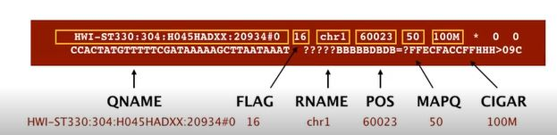

```r
knitr::include_graphics("Captura0001.jpg")
```

**SAM ALINEAMIENTO, haz click para expandir**

- **QNAME**: el nombre de la lectura
- **FALG**: la bandera bit a bit, que contiene información sobre el alineación
- **RNAME**: el nombre de referencia a la que se alineó la El nombre de referencia debe en el encabezado SAM como una entrada SQ. Si el read no está alineado, esta entrada puede ser *.
- **POS**: la posición en la secuencia de referencia usando indexación basada en 1 de la primera base mapeo en la secuencia de consulta. Esto puede ser cero si la lectura no se alinea.
- **MAPQ**: la calidad del mapeo, que es una medida de la probabilidad de lectura es en realidad originarse en la posición a la que se asigna. Calidad de mapeo es estimado por el alineador. Muchas herramientas después del filtro de alineadores out lee ese mapa con baja calidad de mapeo.
- **CIGAR**: la cadena CIGAR, que es un formato especializado para describir la alineación
- **RNEXT y PNEXT** (en la siguiente línea): el nombre de referencia y la posición de un par disponible. El valor * indica que el RNEXT no estaa disponible y = indica que RNEXT es lo mismo que RNAME. PNEXT será 0 cuando no esté disponible.
- **TLEN**: la longitud de la plantilla para lecturas de extremos emparejados. El campo TLEN es positivo para el segmento más a la izquierda de la plantilla, negativo para el más a la derecha
- **SEQ**: la secuencia de lectura original. Esta secuencia siempre estará en orientación en la que se alineó y esto puede ser el complemento inverso de la secuencia de lectura original. Si su lectura se alineó con la hebra inversa, que es información guardada en el campo de bandera bit a bit, esta secuencia Sea el complemento inverso.
- **QUAL**: la calidad base de lectura original.

**Bitwise flags**

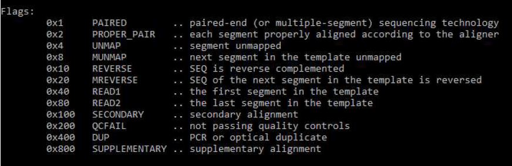

```r
knitr::include_graphics("Captura0002.jpg")
```

Como ejemplo, suponga que encuentra el bit-flag 147 (0x93 en hexadecimal) y quiere saber qué dice esto sobre esto alineación. En binario, este número se representa como 10010011.

**CIGAR strings**

CIGAR (Representación de Alineación Brecha Idiosincrásica Compacta)

Las cadenas son otra forma especializada de codificar información sobre un secuencia alineada. Mientras que las banderas bit a bit almacenan propiedades de verdadero/falso sobre una alineación, Las cadenas CIGAR codifican información sobre qué bases de una alineación son coincidencias/desajustes, inserciones, eliminaciones, recorte suave o duro, etcétera.

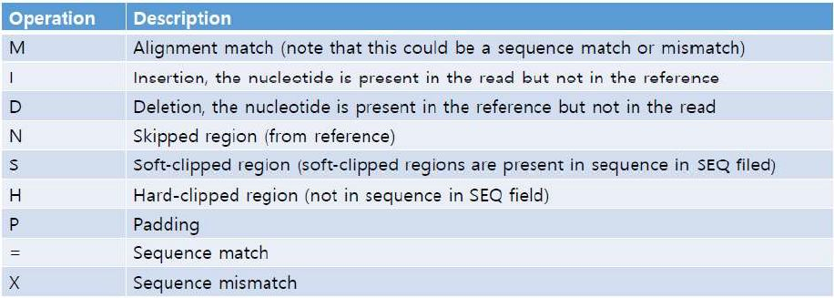

```r
knitr::include_graphics("Captura0003.jpg")
```

“QC of aligned reads” se refiere a la calidad del control de calidad (QC, por sus siglas en inglés) de las lecturas alineadas. Una vez que las secuencias de lectura se han alineado con un genoma de referencia, es importante evaluar la calidad de los resultados del alineamiento para determinar si son confiables y cumplen con ciertos criterios de calidad.

El QC de las lecturas alineadas puede implicar una variedad de pasos y medidas, que pueden incluir:

Estadísticas básicas: Se pueden calcular estadísticas básicas, como el número total de lecturas alineadas, la cobertura promedio, la longitud promedio de las lecturas, etc. Estas estadísticas proporcionan una idea general de la calidad y la distribución de las lecturas alineadas.

Filtrado de lecturas: Se pueden aplicar criterios de filtrado para eliminar lecturas de baja calidad o lecturas que no cumplen con ciertos requisitos predefinidos. Esto puede incluir el filtrado basado en la calidad de las bases, la eliminación de adaptadores o secuencias contaminantes, o la eliminación de lecturas con un bajo mapeo de calidad.

Cálculo de la calidad del mapeo: Se pueden calcular medidas de calidad del mapeo para evaluar la confiabilidad de las lecturas alineadas. Esto puede incluir la calidad de mapeo individual de cada lectura, la distribución de las puntuaciones de mapeo, la proporción de lecturas únicas o múltiples que se alinearon, etc.

Análisis de duplicados: Se pueden identificar y eliminar duplicados de lecturas alineadas que pueden haberse generado durante la amplificación o la secuenciación. La presencia de duplicados puede sesgar los análisis posteriores, y su eliminación ayuda a obtener resultados más precisos.

Visualización y exploración de los resultados: Se pueden generar gráficos y visualizaciones para explorar los resultados del alineamiento y detectar posibles problemas o patrones. Esto puede incluir la visualización de la cobertura del genoma, la distribución de las puntuaciones de mapeo, el conteo de lecturas en regiones específicas, etc.

```r
bam.files <- list.files(path = "C:/Users/polo/OneDrive/ZZZ/00GENESPECTRUM/00TALLER/SESION06", pattern = ".BAM$", full.names = TRUE)
bam.files
```

```
 [1] "C:/Users/polo/OneDrive/ZZZ/00GENESPECTRUM/00TALLER/SESION06/SRR1552444.fastq.subread.BAM"
 [2] "C:/Users/polo/OneDrive/ZZZ/00GENESPECTRUM/00TALLER/SESION06/SRR1552445.fastq.subread.BAM"
 [3] "C:/Users/polo/OneDrive/ZZZ/00GENESPECTRUM/00TALLER/SESION06/SRR1552446.fastq.subread.BAM"
 [4] "C:/Users/polo/OneDrive/ZZZ/00GENESPECTRUM/00TALLER/SESION06/SRR1552447.fastq.subread.BAM"
 [5] "C:/Users/polo/OneDrive/ZZZ/00GENESPECTRUM/00TALLER/SESION06/SRR1552448.fastq.subread.BAM"
 [6] "C:/Users/polo/OneDrive/ZZZ/00GENESPECTRUM/00TALLER/SESION06/SRR1552449.fastq.subread.BAM"
 [7] "C:/Users/polo/OneDrive/ZZZ/00GENESPECTRUM/00TALLER/SESION06/SRR1552450.fastq.subread.BAM"
 [8] "C:/Users/polo/OneDrive/ZZZ/00GENESPECTRUM/00TALLER/SESION06/SRR1552451.fastq.subread.BAM"
 [9] "C:/Users/polo/OneDrive/ZZZ/00GENESPECTRUM/00TALLER/SESION06/SRR1552452.fastq.subread.BAM"
[10] "C:/Users/polo/OneDrive/ZZZ/00GENESPECTRUM/00TALLER/SESION06/SRR1552453.fastq.subread.BAM"
[11] "C:/Users/polo/OneDrive/ZZZ/00GENESPECTRUM/00TALLER/SESION06/SRR1552454.fastq.subread.BAM"
[12] "C:/Users/polo/OneDrive/ZZZ/00GENESPECTRUM/00TALLER/SESION06/SRR1552455.fastq.subread.BAM"
```

```r
start_time <- Sys.time()

props <- propmapped(files=bam.files)
head(props)
```

```
                             NumTotal NumMapped PropMapped     NA
SRR1552444.fastq.subread.BAM    10000      1489          0 148900
SRR1552445.fastq.subread.BAM    10000      1443          0 144300
SRR1552446.fastq.subread.BAM    10000      1265          0 126500
SRR1552447.fastq.subread.BAM    10000      1188          0 118800
SRR1552448.fastq.subread.BAM    10000       732          0  73200
SRR1552449.fastq.subread.BAM    10000       651          0  65100
```

```r
end_time <- Sys.time()
tiempo_total<-end_time - start_time
tiempo_total
```

```
Time difference of 39.38244 secs
```

**ALINEAMIENTO con bowtie2**.

**PASOS**

- Descomprimir todos los archivos gz con “gunzip”:
- Cree el índice del genoma para bowtie2 con “bowtie2_build”
- Alinee los archivos FASTQ contra el genoma indexado con “bowtie2”
- Convierta archivos SAM en BAM (e indexe .bai) con “asBam”
- Para verificar el contenido del archivo gff3:
- file.show(“genes/Saccharomyces_cerevisiae.R64-1-1.99.gff3”)
- almacene todas las rutas de los archivos bam en el objeto R “bamFiles” (utilice “list.files”)
- cuantifique los “genes” con “featureCounts” y almacene los resultados en los “datos” del objeto R
- Cree un data.frame para almacenar todos los grupos replicados. EN EL MISMO ORDEN QUE “bamFiles
- Use “DESeqDataSetFromMatrix” para reparar todos los recuentos sin procesar y el diseño experimental:
- Utilice la función “DESeq” para normalizar y calcular las dispersiones de los datos de expresión génica
- Utilice la función “results” para obtener log2Ratios, pvalues… para la comparación de interés:
- NOTA: contraste = [nombre de columna en el marco de datos “thesamples”], [numerador], [denominador]
- Prepara una bonita tabla (data.frame) con todos los resultados:
- Utilice “write.table” para crear un archivo de texto tabulado
- Cargue un archivo tabulado con texto en el visor FIESTA para crear un diagrama MA interactivo:

**creamos el indice**.

```r
start_time <- Sys.time()

bowtie2_build("C:/Users/polo/OneDrive/ZZZ/00GENESPECTRUM/00TALLER/SESION06/RNASeq_Data/chr1.fa",
               bt2Index = "C:/Users/polo/OneDrive/ZZZ/00GENESPECTRUM/00TALLER/SESION06/RNASeq_Data/tettt",
               overwrite = TRUE)

end_time <- Sys.time()
tiempo_total<-end_time - start_time
tiempo_total
```

alineamos los FASTQ contra el genoma indexado con “bowtie2

```r
 bowtie2(bt2Index = "C:/Users/polo/OneDrive/ZZZ/00GENESPECTRUM/00TALLER/SESION06/RNASeq_Data/tettt",
         samOutput = "C:/Users/polo/OneDrive/ZZZ/00GENESPECTRUM/00TALLER/SESION06/RNASeq_Data/SRR1552444.sam",
         seq1 = "C:/Users/polo/OneDrive/ZZZ/00GENESPECTRUM/00TALLER/SESION06/RNASeq_Data/SRR1552444.fastq",
         "--threads=3")
```

```r
 bowtie2(bt2Index = "C:/Users/polo/OneDrive/ZZZ/00GENESPECTRUM/00TALLER/SESION06/RNASeq_Data/tettt",
         samOutput = "C:/Users/polo/OneDrive/ZZZ/00GENESPECTRUM/00TALLER/SESION06/RNASeq_Data/SRR1552445.sam",
         seq1 = "C:/Users/polo/OneDrive/ZZZ/00GENESPECTRUM/00TALLER/SESION06/RNASeq_Data/SRR1552445.fastq",
         "--threads=3")
```

```r
 bowtie2(bt2Index = "C:/Users/polo/OneDrive/ZZZ/00GENESPECTRUM/00TALLER/SESION06/RNASeq_Data/tettt",
         samOutput = "C:/Users/polo/OneDrive/ZZZ/00GENESPECTRUM/00TALLER/SESION06/RNASeq_Data/SRR1552446.sam",
         seq1 = "C:/Users/polo/OneDrive/ZZZ/00GENESPECTRUM/00TALLER/SESION06/RNASeq_Data/SRR1552446.fastq",
         "--threads=3")
```

```r
 bowtie2(bt2Index = "C:/Users/polo/OneDrive/ZZZ/00GENESPECTRUM/00TALLER/SESION06/RNASeq_Data/tettt",
         samOutput = "C:/Users/polo/OneDrive/ZZZ/00GENESPECTRUM/00TALLER/SESION06/RNASeq_Data/SRR1552447.sam",
         seq1 = "C:/Users/polo/OneDrive/ZZZ/00GENESPECTRUM/00TALLER/SESION06/RNASeq_Data/SRR1552447.fastq",
         "--threads=3")
```

```r
 bowtie2(bt2Index = "C:/Users/polo/OneDrive/ZZZ/00GENESPECTRUM/00TALLER/SESION06/RNASeq_Data/tettt",
         samOutput = "C:/Users/polo/OneDrive/ZZZ/00GENESPECTRUM/00TALLER/SESION06/RNASeq_Data/SRR1552448.sam",
         seq1 = "C:/Users/polo/OneDrive/ZZZ/00GENESPECTRUM/00TALLER/SESION06/RNASeq_Data/SRR1552448.fastq",
         "--threads=3")
```

```r
 bowtie2(bt2Index = "C:/Users/polo/OneDrive/ZZZ/00GENESPECTRUM/00TALLER/SESION06/RNASeq_Data/tettt",
         samOutput = "C:/Users/polo/OneDrive/ZZZ/00GENESPECTRUM/00TALLER/SESION06/RNASeq_Data/SRR1552449.sam",
         seq1 = "C:/Users/polo/OneDrive/ZZZ/00GENESPECTRUM/00TALLER/SESION06/RNASeq_Data/SRR1552449.fastq",
         "--threads=3")
```

```r
 bowtie2(bt2Index = "C:/Users/polo/OneDrive/ZZZ/00GENESPECTRUM/00TALLER/SESION06/RNASeq_Data/tettt",
         samOutput = "C:/Users/polo/OneDrive/ZZZ/00GENESPECTRUM/00TALLER/SESION06/RNASeq_Data/SRR1552450.sam",
         seq1 = "C:/Users/polo/OneDrive/ZZZ/00GENESPECTRUM/00TALLER/SESION06/RNASeq_Data/SRR1552450.fastq",
         "--threads=3")
```

```r
 bowtie2(bt2Index = "C:/Users/polo/OneDrive/ZZZ/00GENESPECTRUM/00TALLER/SESION06/RNASeq_Data/tettt",
         samOutput = "C:/Users/polo/OneDrive/ZZZ/00GENESPECTRUM/00TALLER/SESION06/RNASeq_Data/SRR1552451.sam",
         seq1 = "C:/Users/polo/OneDrive/ZZZ/00GENESPECTRUM/00TALLER/SESION06/RNASeq_Data/SRR1552451.fastq",
         "--threads=3")
```

```r
 bowtie2(bt2Index = "C:/Users/polo/OneDrive/ZZZ/00GENESPECTRUM/00TALLER/SESION06/RNASeq_Data/tettt",
         samOutput = "C:/Users/polo/OneDrive/ZZZ/00GENESPECTRUM/00TALLER/SESION06/RNASeq_Data/SRR1552452.sam",
         seq1 = "C:/Users/polo/OneDrive/ZZZ/00GENESPECTRUM/00TALLER/SESION06/RNASeq_Data/SRR1552452.fastq",
         "--threads=3")
```

```r
 bowtie2(bt2Index = "C:/Users/polo/OneDrive/ZZZ/00GENESPECTRUM/00TALLER/SESION06/RNASeq_Data/tettt",
         samOutput = "C:/Users/polo/OneDrive/ZZZ/00GENESPECTRUM/00TALLER/SESION06/RNASeq_Data/SRR1552453.sam",
         seq1 = "C:/Users/polo/OneDrive/ZZZ/00GENESPECTRUM/00TALLER/SESION06/RNASeq_Data/SRR1552452.fastq",
         "--threads=3")
```

```r
 bowtie2(bt2Index = "C:/Users/polo/OneDrive/ZZZ/00GENESPECTRUM/00TALLER/SESION06/RNASeq_Data/tettt",
         samOutput = "C:/Users/polo/OneDrive/ZZZ/00GENESPECTRUM/00TALLER/SESION06/RNASeq_Data/SRR1552454.sam",
         seq1 = "C:/Users/polo/OneDrive/ZZZ/00GENESPECTRUM/00TALLER/SESION06/RNASeq_Data/SRR1552453.fastq",
         "--threads=3")
```

```r
 bowtie2(bt2Index = "C:/Users/polo/OneDrive/ZZZ/00GENESPECTRUM/00TALLER/SESION06/RNASeq_Data/tettt",
         samOutput = "C:/Users/polo/OneDrive/ZZZ/00GENESPECTRUM/00TALLER/SESION06/RNASeq_Data/SRR1552455.sam",
         seq1 = "C:/Users/polo/OneDrive/ZZZ/00GENESPECTRUM/00TALLER/SESION06/RNASeq_Data/SRR1552454.fastq",
         "--threads=3")
```

```r
asBam("C:/Users/polo/OneDrive/ZZZ/00GENESPECTRUM/00TALLER/SESION06/RNASeq_Data/SRR1552444.sam")
asBam("C:/Users/polo/OneDrive/ZZZ/00GENESPECTRUM/00TALLER/SESION06/RNASeq_Data/SRR1552445.sam")
asBam("C:/Users/polo/OneDrive/ZZZ/00GENESPECTRUM/00TALLER/SESION06/RNASeq_Data/SRR1552446.sam")
asBam("C:/Users/polo/OneDrive/ZZZ/00GENESPECTRUM/00TALLER/SESION06/RNASeq_Data/SRR1552447.sam")
asBam("C:/Users/polo/OneDrive/ZZZ/00GENESPECTRUM/00TALLER/SESION06/RNASeq_Data/SRR1552448.sam")
asBam("C:/Users/polo/OneDrive/ZZZ/00GENESPECTRUM/00TALLER/SESION06/RNASeq_Data/SRR1552449.sam")
asBam("C:/Users/polo/OneDrive/ZZZ/00GENESPECTRUM/00TALLER/SESION06/RNASeq_Data/SRR1552450.sam")
asBam("C:/Users/polo/OneDrive/ZZZ/00GENESPECTRUM/00TALLER/SESION06/RNASeq_Data/SRR1552451.sam")
asBam("C:/Users/polo/OneDrive/ZZZ/00GENESPECTRUM/00TALLER/SESION06/RNASeq_Data/SRR1552452.sam")
asBam("C:/Users/polo/OneDrive/ZZZ/00GENESPECTRUM/00TALLER/SESION06/RNASeq_Data/SRR1552453.sam")
asBam("C:/Users/polo/OneDrive/ZZZ/00GENESPECTRUM/00TALLER/SESION06/RNASeq_Data/SRR1552454.sam")
asBam("C:/Users/polo/OneDrive/ZZZ/00GENESPECTRUM/00TALLER/SESION06/RNASeq_Data/SRR1552455.sam")
```

almacenar todas las rutas bam en una variable llamada bamFIles usando “list.files”

```r
bamFiles <- list.files(path="C:/Users/polo/OneDrive/ZZZ/00GENESPECTRUM/00TALLER/SESION06/RNASeq_Data/", pattern="*.bam$", full.names=TRUE)
```

```r
see <- file.show("C:/Users/polo/OneDrive/ZZZ/00GENESPECTRUM/00TALLER/SESION06/mm39.ensGene.v104.gtf")
```

cuantificar genes con “featureCounts” y almacenamos el resultado en una variable llamada “data”

```r
data <- featureCounts(
                     files = bamFiles,
                 annot.ext = "C:/Users/polo/OneDrive/ZZZ/00GENESPECTRUM/00TALLER.gtf",
           isGTFAnnotation = TRUE,
           GTF.featureType = "gene",     # vemos los genes no otra cosa (intrones, exones, ...)
              GTF.attrType = "ID",       # cogemos el atribulo id de la tabla
               isPairedEnd = NOT,        # si paire end
     requireBothEndsMapped = TRUE,
                    minMQS = 20,         # control de calidad (20, 30)
            strandSpecific = 2           # especificdad de cadadena 2
        )
```

**LO MISMO PERO CON BUCLES For, haz click para expandir**

:

**LEEMOS TODOS LOS ARCHIVOS EN UN DIRECTORIO:**

- compressedFastq <- list.files(path=“SES07/fastq_50k/”, pattern=“*.fastq.gz$“, full.names=TRUE)

**DESCOMPRIMINOS TODOS LOS ARCHIVOS ANTERIORES:**

- for (t in 1:NROW(compressedFastq)){ gunzip(compressedFastq[t], remove=FALSE) }

**GUARDAMOS EN VARIABLES LAS SERIES _1 Y LAS _2:**

- allFastq_1 <- list.files(path=“SES07/fastq_50k/”, pattern=“*_1.fastq$“, full.names=TRUE)
- allFastq_2 <- list.files(path=“SES07/fastq_50k/”, pattern=“*_2.fastq$“, full.names=TRUE)

**CREAMOS UN DATA FRAME; EN UNA COLUMNA TENDREMOS LA SERIA _1 Y EN OTRA LA _2**

- PROJECT <- data.frame(fastq_1 = allFastq_1, fastq_2 = allFastq_2)
- PROJECT

**LO PODEMOS ESCRIBIR EN UNA TABLA**

- write.table(PROJECT, file=“SES07/myproject.tsv”, sep=“, row.names=FALSE)

**ABRIMOS y cargamos EL .tsv E INCLUIMOS DOS COLUMNAS A MANO: 1.- condictions; 2.- replicate**

- PROJECT <- read.table(“SES07/myproject.tsv”, header=TRUE, sep=“)
- PROJECT

**INDEXAMOS EL GEN DE LA LEVADURA**

- bowtie2_build(“SES07/chromosomes/Saccharomyces_cerevisiae.R64-1-1.dna.toplevel.fa”, bt2Index = “SES07/chromosomes/yeast”)

**ALINEAMOS**

- dir.create(“SES07/aligned”) # CREAMOS UNA CARPETA
- names(PROJECT)
- bamFiles <- vector()
- for(t in 1:NROW(PROJECT)){
  - myfq1 <- PROJECT$fastq_1[t]
  - myfq2 <- PROJECT$fastq_2[t]
  - mysam <- paste0(“SES07/aligned/”, PROJECT$condictions[t], "-", PROJECT$replicate[t], “.sam”)
  - bowtie2(bt2Index = “SES07/chromosomes/yeast”, samOutput = mysam, seq1 = myfq1, seq2 = myfq2, “–threads=3”)
  - asBam(mysam)
  - bamFiles[t] <- paste0(“SES07/aligned/”, PROJECT$condictions[t], "-", PROJECT$replicate[t], “.bam”)}

**CON EL MISMO ORDEN QU LA TABLA .tsv**

- bamFiles <- vector()
- for(t in 1:NROW(PROJECT)){
  - bamFiles[t] <- paste0(“SES07/aligned/”, PROJECT$condictions[t], "-", PROJECT$replicate[t], “.bam”)}
- bamFiles

**CUANTIFICAMOS LOS ARCHIVOS BAM (?featureCounts)**

data <- featureCounts(  
files = bamFiles, **ARCHIVOS BAM, EN ESTE ORDEN**  
annot.ext = “SES07/genes/Saccharomyces_cerevisiae.R64-1-1.99.gff3”, **PARA SABER LAS COORDENADAS DE LOS GENES**  
isGTFAnnotation = TRUE, **ES LO MISMO GTF QUE GFF3**  
GTF.featureType = “gene”, **DENTRO DEL GFF3, SOLO LAS LINEAS gene**  
GTF.attrType = “ID”, **USAMOS EL ID PARA PONER NOMBRE A LOS GENES**  
isPairedEnd = TRUE, **SON DATOS PAIRES-END**  
requireBothEndsMapped = TRUE, **QUEREMOS QUE LOS DOS MIEMBROS DE LA PAREJA ESTEN MAPEADOS**  
minMQS = 20, **CALIDAD MINIMA DEL ALINEAMIENTO DE 20**  
strandSpecific = 2, **ESPCIFIDAD DE HEBRA 2**  
ignoreDup = FALSE, **IGNORAR DUPLICADOS MARCADOS CON EL FLAG**  
nthreads = 3  
)

**CONTROL DE CALIDAD**.

El porcentaje de lecturas mapeadas es un indicador global del total precisión de la secuenciación y de la presencia de ADN contaminante.

Esperamos que el 70-90% de las lecturas regulares de secuencias de ARN se mapeen en el genoma dependiendo del mapeador de lecturas utilizado (con una fracción significativa de lecturas de mapeo múltiple)

Cuando las lecturas se mapean contra el transcriptoma, esperamos un poco porcentajes de mapeo total más bajos y más lecturas de mapeo múltiple.

Podemos echar un vistazo a las puntuaciones de calidad asociadas con cada base que ha sido llamada por la máquina de secuenciación utilizando la función en Rsubread “qualityScores”

Primero extraigamos las puntuaciones de calidad para 10000 lecturas

```r
qs_A <- qualityScores(filename="SRR1552444.fastq.subread.BAM", input_format = "bam", nreads=10000)
```

```
qualityScores Rsubread 2.12.3

Scan the input file...
Totally 10000 reads were scanned; the sampling interval is 1.
Now extract read quality information...

Completed successfully. Quality scores for 10000 reads (equally spaced in the file) are returned.
```

```r
qs_B <- qualityScores(filename="SRR1552445.fastq.subread.BAM", input_format = "bam", nreads=10000)
```

```
qualityScores Rsubread 2.12.3

Scan the input file...
Totally 10000 reads were scanned; the sampling interval is 1.
Now extract read quality information...

Completed successfully. Quality scores for 10000 reads (equally spaced in the file) are returned.
```

```r
dim(qs_A)
```

```
[1] 10000   100
```

```r
# head(qs)
```

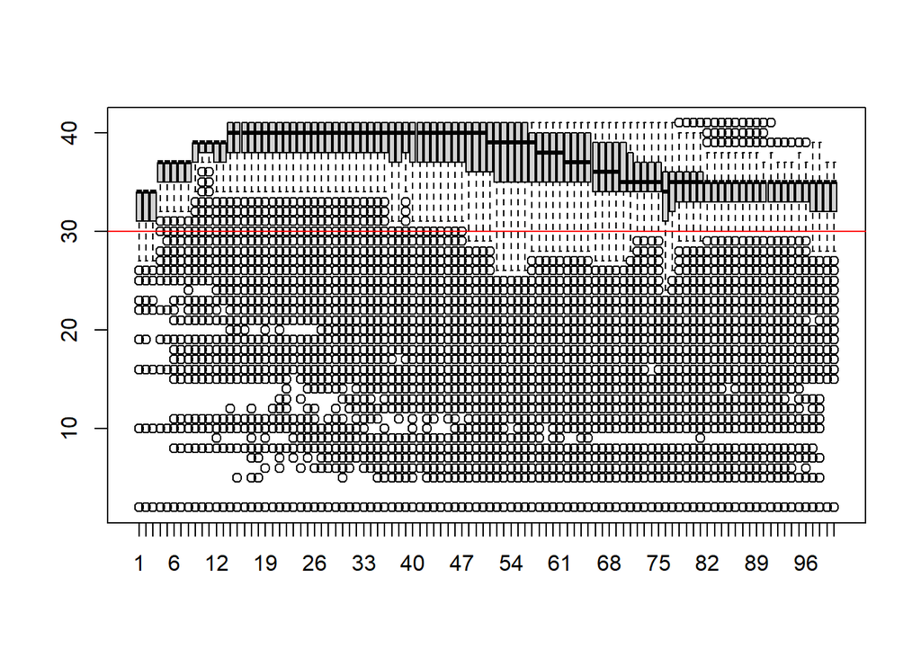

```r
boxplot(qs_A)
abline(h = 30, col= "red")
```

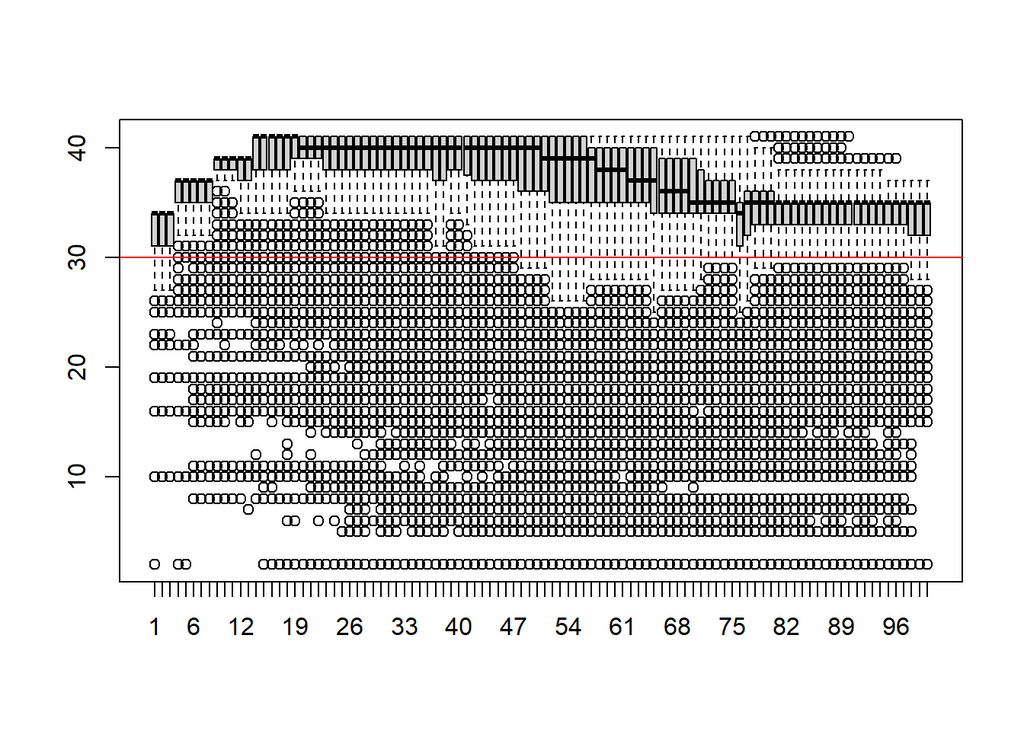

```r
boxplot(qs_B)
abline(h = 30, col= "red")
```

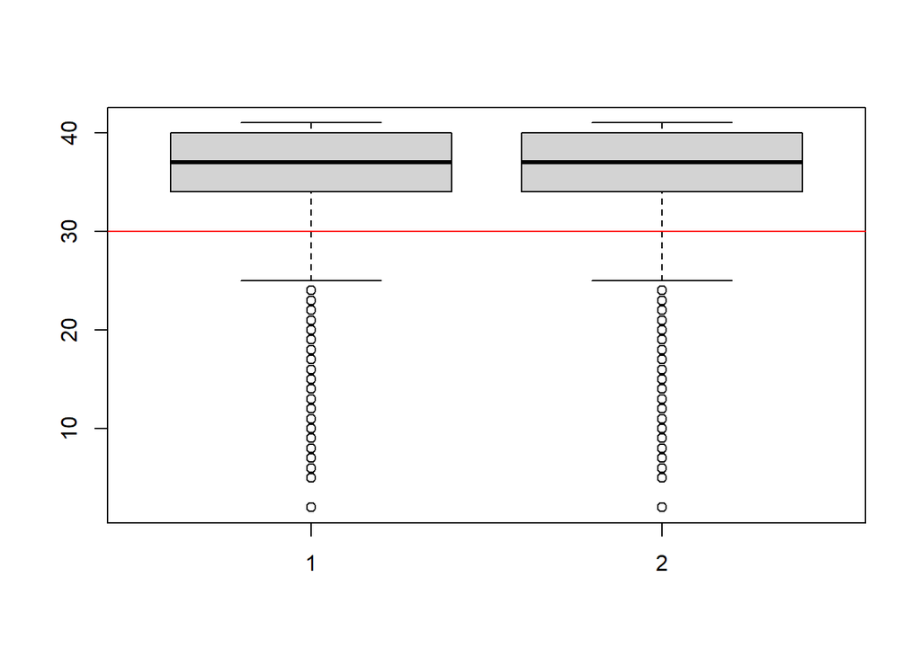

```r
list_qs <- list(A,B)
# list_qs
boxplot(list_qs)
abline(h = 30, col= "red")
```

**PARAMETROS DE LA FUNCION featureCounts, haz click para expandir**

:

- **files**: un vector de caracteres que contiene los nombres de archivo de las lecturas de RNA-seq. Estos archivos pueden estar en formato SAM, BAM o BED.
- **annot.ext**: un objeto de anotación de genes, que puede ser un archivo GTF o SAF o un objeto GRanges de Bioconductor. Este objeto contiene información sobre la ubicación y la estructura de los genes.
- **isGTFAnnotationFile:** un valor lógico que indica si el archivo de anotación es un archivo GTF. Si se establece en TRUE, se usará la columna gene_id para agrupar las lecturas y contarlas por gen. Si se establece en FALSE, se usará la columna Name para agrupar las lecturas y contarlas por característica.
- **GTF.featureType**: una cadena que especifica el tipo de característica que se debe utilizar para contar las lecturas si isGTFAnnotationFile se establece en TRUE. El valor predeterminado es “exon”.
- **GTF.attrType**: una cadena que especifica el atributo que se debe utilizar para asignar las lecturas a los genes si isGTFAnnotationFile se establece en TRUE. El valor predeterminado es “gene_id”.
- **nthreads:** el número de hilos de procesamiento que se deben utilizar para contar las lecturas. El valor predeterminado es 1.
- **isPairedEnd**: un valor lógico que indica si las lecturas de RNA-seq son de extremo emparejado o no. El valor predeterminado es FALSE.
- **countMultiMappingReads**: un valor lógico que indica si se deben contar las lecturas que se asignan a varias características. El valor predeterminado es TRUE.
- **requireBothEndsMapped**: un valor lógico que indica si se deben contar solo las lecturas que tienen ambos extremos mapeados a la característica de interés. El valor predeterminado es FALSE.
- **checkFragLength**: un valor lógico que indica si se deben verificar las longitudes de fragmento de las lecturas de RNA-seq. Si se establece en TRUE, se excluirán las lecturas que tengan longitudes de fragmento fuera del rango de ±5 desviaciones estándar de la media. El valor predeterminado es FALSE.
- **requireBothEndsAdjacent**: un valor lógico que indica si se deben contar solo las lecturas que tienen ambos extremos mapeados adyacentes a la característica de interés. El valor predeterminado es FALSE.
- **readExtensions**: un vector numérico que especifica la longitud adicional que se debe agregar a cada lectura para incluir las regiones flanqueantes. El primer valor del vector se aplica al extremo 5 ‘y el segundo valor se aplica al extremo 3’. El valor predeterminado es c(0, 0).
- **readTimeout**: un valor numérico que especifica el tiempo de espera máximo (en segundos) para la lectura de archivos de lecturas de RNA-seq. El valor predeterminado es NULL, lo que significa que no hay tiempo de espera. primaryOnly: un valor lógico que indica si se deben contar solo las lecturas que se asignan a la característica principal.

**CONTAR**.

El siguiente código utiliza los intervalos de exón definidos en la anotación NCBI refseq del genoma mm10. Las lecturas que se asignan a los exones de los genes se suman para obtener el recuento de cada gen, con cierto cuidado con las lecturas que abarcan los límites exón-exón. toma todos los archivos BAM como entrada y genera un objeto que incluye la matriz de recuento. Cada muestra es una columna separada, cada fila es un gen.featureCounts

```r
start_time <- Sys.time()

fc <- featureCounts(bam.files, annot.inbuilt="mm10")
```

```
NCBI RefSeq annotation for mm10 (build 38.1) is used.

        ==========     _____ _    _ ____  _____  ______          _____
        =====         / ____| |  | |  _ \|  __ \|  ____|   /\   |  __ \
          =====      | (___ | |  | | |_) | |__) | |__     /  \  | |  | |
            ====      \___ \| |  | |  _ <|  _  /|  __|   / /\ \ | |  | |
              ====    ____) | |__| | |_) | | \ \| |____ / ____ \| |__| |
        ==========   |_____/ \____/|____/|_|  \_\______/_/    \_\_____/
       Rsubread 2.12.3

//========================== featureCounts setting ===========================\\
||                                                                            ||
||             Input files : 12 BAM files                                     ||
||                                                                            ||
||                           SRR1552444.fastq.subread.BAM                     ||
||                           SRR1552445.fastq.subread.BAM                     ||
||                           SRR1552446.fastq.subread.BAM                     ||
||                           SRR1552447.fastq.subread.BAM                     ||
||                           SRR1552448.fastq.subread.BAM                     ||
||                           SRR1552449.fastq.subread.BAM                     ||
||                           SRR1552450.fastq.subread.BAM                     ||
||                           SRR1552451.fastq.subread.BAM                     ||
||                           SRR1552452.fastq.subread.BAM                     ||
||                           SRR1552453.fastq.subread.BAM                     ||
||                           SRR1552454.fastq.subread.BAM                     ||
||                           SRR1552455.fastq.subread.BAM                     ||
||                                                                            ||
||              Paired-end : no                                               ||
||        Count read pairs : no                                               ||
||              Annotation : inbuilt (mm10)                                   ||
||      Dir for temp files : .                                                ||
||                 Threads : 1                                                ||
||                   Level : meta-feature level                               ||
||      Multimapping reads : counted                                          ||
|| Multi-overlapping reads : not counted                                      ||
||   Min overlapping bases : 1                                                ||
||                                                                            ||
\\============================================================================//

//================================= Running ==================================\\
```

[output cut: 67 more lines]

```
||    Single-end reads are included.                                          ||
||    Total alignments : 10000                                                ||
||    Successfully assigned alignments : 546 (5,5%)                           ||
||    Running time : 0,00 minutes                                             ||
||                                                                            ||
|| Process BAM file SRR1552455.fastq.subread.BAM...                           ||
||    Single-end reads are included.                                          ||
||    Total alignments : 10000                                                ||
||    Successfully assigned alignments : 528 (5,3%)                           ||
||    Running time : 0,00 minutes                                             ||
||                                                                            ||
|| Write the final count table.                                               ||
|| Write the read assignment summary.                                         ||
||                                                                            ||
\\============================================================================//
```

```r
end_time <- Sys.time()
tiempo_total<-end_time - start_time
tiempo_total
```

```
Time difference of 2.651071 secs
```

El código toma como entrada una lista de archivos BAM (“bam.files”) que contienen datos de alineación de lecturas obtenidas a partir de experimentos de secuenciación de ARN. Además, utiliza la anotación genómica incorporada “mm10” (correspondiente al genoma de ratón) para asignar cada lectura al gen o la región genómica correspondiente.

La función “featureCounts” cuenta el número de lecturas que se alinean con cada gen o característica genómica especificada en la anotación, y devuelve una tabla que contiene el número de lecturas contadas para cada gen o característica genómica.

El resultado final de este código será una tabla que contiene información sobre el número de lecturas que se alinean con cada característica genómica especificada en la anotación “mm10” para cada archivo BAM proporcionado en la lista “bam.files”.

```r
names(fc)
```

```
[1] "counts"     "annotation" "targets"    "stat"
```

**“counts”**: representa una matriz que contiene el número de lecturas contadas para cada característica genómica especificada en la anotación genómica para cada archivo de alineación de lectura en la lista “bam.files”. **“annotation”**: representa la anotación genómica utilizada para realizar la asignación de lecturas a características genómicas. En este caso, la anotación incorporada “mm10” (correspondiente al genoma de ratón). **“targets”**: representa la lista de características genómicas utilizadas para el recuento de lecturas. Estos pueden ser genes, exones, intrones, regiones no codificantes, etc., según lo especificado en la anotación genómica. **“stat”**: representa una matriz que contiene información estadística sobre el proceso de conteo de lecturas, como el número de lecturas totales procesadas, el número de lecturas asignadas a características genómicas únicas, el número de lecturas asignadas a características genómicas múltiples, el número de lecturas descartadas y el número de lecturas que no se pudieron asignar a características genómicas.

Las estadísticas del mapeo de lectura se pueden ver con fc$stats.

**SALIDAS DE fc$stast, haz click para expandir**

:

- **Assigned**: El número de lecturas asignadas a características genómicas únicas. Es decir, el número de lecturas que se alinean exclusivamente con una sola característica genómica de la anotación.
- **Unassigned_Unmapped**: El número de lecturas que no se pudieron alinear al genoma de referencia.
- **Unassigned_MappingQuality**: El número de lecturas que se alinearon al genoma de referencia pero que no cumplen con el umbral de calidad de mapeo establecido.
- **Unassigned_Chimera**: El número de lecturas que se alinean con múltiples ubicaciones diferentes en el genoma de referencia y, por lo tanto, se consideran quimeras.
- **Unassigned_FragmentLength**: El número de pares de lecturas que se alinearon correctamente, pero cuya longitud de fragmento es inconsistente con la biblioteca de secuenciación.
- **Unassigned_Duplicate**: El número de lecturas marcadas como duplicadas en el archivo de alineación.
- **MultiMapping**: El número de lecturas que se alinean con múltiples características genómicas en la anotación.
- **NoFeature**: El número de lecturas que se alinean al genoma de referencia, pero que no se asignan a ninguna característica genómica en la anotación.
- **Ambiguity**: El número de lecturas que se alinean con múltiples características genómicas, pero no se pueden resolver debido a la ambigüedad en la anotación genómica.
- **TooShort**: El número de lecturas que se consideran demasiado cortas para una asignación precisa.

```r
fc$stat
```

```
                          Status SRR1552444.fastq.subread.BAM SRR1552445.fastq.subread.BAM SRR1552446.fastq.subread.BAM SRR1552447.fastq.subread.BAM
1                       Assigned                          482                          466                          376                          350
2            Unassigned_Unmapped                         8511                         8557                         8735                         8812
3           Unassigned_Read_Type                            0                            0                            0                            0
4           Unassigned_Singleton                            0                            0                            0                            0
5      Unassigned_MappingQuality                            0                            0                            0                            0
6             Unassigned_Chimera                            0                            0                            0                            0
7      Unassigned_FragmentLength                            0                            0                            0                            0
8           Unassigned_Duplicate                            0                            0                            0                            0
9        Unassigned_MultiMapping                            0                            0                            0                            0
10          Unassigned_Secondary                            0                            0                            0                            0
11           Unassigned_NonSplit                            0                            0                            0                            0
12         Unassigned_NoFeatures                          994                          970                          883                          825
13 Unassigned_Overlapping_Length                            0                            0                            0                            0
14          Unassigned_Ambiguity                           13                            7                            6                           13
```

[output cut: 30 more lines]

```r
# fc$counts

dim(fc$counts)
```

```
[1] 27179    12
```

```r
#head(fc$counts)


data.table(fc$counts, extensions = "Buttons",
               options = list(dom = "Bfrtip",
               buttons = c("copy", "csv", "excel", "print", "PDF")))
```

```
       SRR1552444.fastq.subread.BAM SRR1552445.fastq.subread.BAM SRR1552446.fastq.subread.BAM SRR1552447.fastq.subread.BAM
    1:                            0                            0                            0                            0
    2:                            0                            0                            0                            0
    3:                            0                            0                            0                            0
    4:                            0                            0                            0                            0
    5:                            0                            0                            0                            0
   ---
27175:                            0                            0                            0                            0
27176:                            0                            0                            0                            0
27177:                            0                            0                            0                            0
27178:                            0                            0                            0                            0
27179:                            0                            0                            0                            0
       SRR1552448.fastq.subread.BAM SRR1552449.fastq.subread.BAM SRR1552450.fastq.subread.BAM SRR1552451.fastq.subread.BAM
    1:                            0                            0                            0                            0
    2:                            0                            0                            0                            0
```

[output cut: 33 more lines]

Los nombres de fila de la matriz fc$counts representan los identificadores del gen

**SALIDAS DE fc$count, haz click para expandir**

:

La salida de fc$counts es una matriz que contiene el número de lecturas contadas para cada característica genómica especificada en la anotación genómica, para cada archivo de alineación de lectura en la lista “bam.files”.

La matriz tiene un número de filas igual al número de características genómicas en la anotación, y un número de columnas igual al número de archivos de alineación en la lista “bam.files”.

Cada fila de la matriz representa una característica genómica específica (por ejemplo, un gen o una región genómica) y cada columna representa un archivo de alineación. Los valores de la matriz indican el número de lecturas contadas para cada característica genómica en cada archivo de alineación.

Por lo tanto, si se está trabajando con datos de expresión génica, se puede utilizar esta matriz para comparar los niveles de expresión de diferentes genes o regiones genómicas entre diferentes muestras. La matriz también se puede utilizar para realizar análisis de expresión diferencial, identificar genes o regiones genómicas diferencialmente expresados entre diferentes muestras, etc.

```r
names(fc$annotation)
```

```
[1] "GeneID" "Chr"    "Start"  "End"    "Strand" "Length"
```

- **GeneID**, ID del gen
- **Chr**, cromosoma al que corresponde
- **Start**, inicio
- **End**, fin
- **Strand**, hebra de localizacion del gen
- **Length**, longitud

```r
head(fc$annotation, 10)
```

```
      GeneID                                                    Chr
1     497097                                         chr1;chr1;chr1
2  100503874                                              chr1;chr1
3  100038431                                                   chr1
4      19888                          chr1;chr1;chr1;chr1;chr1;chr1
5      20671                               chr1;chr1;chr1;chr1;chr1
6      27395                               chr1;chr1;chr1;chr1;chr1
7      18777           chr1;chr1;chr1;chr1;chr1;chr1;chr1;chr1;chr1
8  100503730                chr1;chr1;chr1;chr1;chr1;chr1;chr1;chr1
9      21399 chr1;chr1;chr1;chr1;chr1;chr1;chr1;chr1;chr1;chr1;chr1
10     58175                     chr1;chr1;chr1;chr1;chr1;chr1;chr1
                                                                                     Start
1                                                                  3214482;3421702;3670552
2                                                                          3647309;3658847
3                                                                                  3680155
```

[output cut: 18 more lines]

```r
head(fc$annotation, 3)
```

```
     GeneID            Chr                   Start                     End Strand Length
1    497097 chr1;chr1;chr1 3214482;3421702;3670552 3216968;3421901;3671498  -;-;-   3634
2 100503874      chr1;chr1         3647309;3658847         3650509;3658904    -;-   3259
3 100038431           chr1                 3680155                 3681788      +   1634
```

**SALIDAS DE fc$annotation, haz click para expandir**

:

La salida de fc$annotation es un objeto que contiene la anotación genómica utilizada por la función “featureCounts” para asignar las lecturas a características genómicas específicas.

La anotación genómica es un archivo que contiene información sobre las características genómicas, como la posición, nombre, tipo y función biológica de los genes, exones, intrones, regiones intergénicas y otras características del genoma. La anotación se utiliza para proporcionar contexto biológico a los datos de secuenciación y permitir la identificación de las características genómicas que están siendo transcritas.

En el caso de fc$annotation, la anotación es incorporada, lo que significa que se utiliza una anotación genómica predefinida, en este caso “mm10”, que corresponde al genoma de ratón.

La anotación se utiliza para asignar las lecturas a características genómicas específicas, como los genes, exones e intrones, en función de la ubicación de la lectura en el genoma. De esta manera, se pueden contar las lecturas que se asignan a cada característica genómica, lo que proporciona información sobre los niveles de expresión de genes específicos y otras características genómicas en la muestra.

> NORMALIZACION: es el primer paso del analisis de expresion genetica diferencial

DESeq2-normalizacion

calcular el factor de normalizacion para cada ejemplo

```r
normalization_factor_sampleA <- median(c(1.28, 1.3, 1.39, 1.35, 0.59))
normalization_factor_sampleB <- median(c(0.78, 0.77, 0.72, 0.74, 1.35))
```

```r
library(edgeR)

countdata <- read.table("C:/Users/polo/OneDrive/ZZZ/00GENESPECTRUM/00TALLER/SESION07/counts.txt", header = TRUE, sep = "\t")
head(countdata, 20)
```

```
          SRR1552444.fastq.gz.subread.BAM SRR1552445.fastq.gz.subread.BAM SRR1552446.fastq.gz.subread.BAM SRR1552447.fastq.gz.subread.BAM
497097                                  0                               0                               0                               0
100503874                               0                               0                               0                               0
100038431                               0                               0                               0                               0
19888                                  10                               3                              10                               2
20671                                  16                              25                              18                               8
27395                                 558                             468                             488                             332
18777                                 798                             843                             658                             632
100503730                               0                               1                               2                               0
21399                                1222                            1138                             979                             819
58175                                 169                             164                             137                              60
108664                               1378                            1432                            1762                            1569
18387                                   0                               0                               0                               0
226304                                  0                               0                               0                               0
12421                                1326                            1418                            1380                            1349
```

[output cut: 48 more lines]

```r
metadata <- read.table("C:/Users/polo/OneDrive/ZZZ/00GENESPECTRUM/00TALLER/SESION07/SampleInfo.txt", header = TRUE, sep = "\t")
head(metadata, 20)
```

```
                          FileName SampleName CellType   Status
1  SRR1552444.fastq.gz.subread.BAM    MCL1-LA  luminal   virgin
2  SRR1552445.fastq.gz.subread.BAM    MCL1-LB  luminal   virgin
3  SRR1552446.fastq.gz.subread.BAM    MCL1-LC  luminal pregnant
4  SRR1552447.fastq.gz.subread.BAM    MCL1-LD  luminal pregnant
5  SRR1552448.fastq.gz.subread.BAM    MCL1-LE  luminal  lactate
6  SRR1552449.fastq.gz.subread.BAM    MCL1-LF  luminal  lactate
7  SRR1552450.fastq.gz.subread.BAM    MCL1-DG    basal   virgin
8  SRR1552451.fastq.gz.subread.BAM    MCL1-DH    basal   virgin
9  SRR1552452.fastq.gz.subread.BAM    MCL1-DI    basal pregnant
10 SRR1552453.fastq.gz.subread.BAM    MCL1-DJ    basal pregnant
11 SRR1552454.fastq.gz.subread.BAM    MCL1-DK    basal  lactate
12 SRR1552455.fastq.gz.subread.BAM    MCL1-DL    basal  lactate
```

```r
myCPM <- cpm(countdata)
head(myCPM, 5)
```

```
          SRR1552444.fastq.gz.subread.BAM SRR1552445.fastq.gz.subread.BAM SRR1552446.fastq.gz.subread.BAM SRR1552447.fastq.gz.subread.BAM
497097                          0.0000000                       0.0000000                       0.0000000                      0.00000000
100503874                       0.0000000                       0.0000000                       0.0000000                      0.00000000
100038431                       0.0000000                       0.0000000                       0.0000000                      0.00000000
19888                           0.4925540                       0.1383652                       0.4539622                      0.09180321
20671                           0.7880865                       1.1530432                       0.8171319                      0.36721283
          SRR1552448.fastq.gz.subread.BAM SRR1552449.fastq.gz.subread.BAM SRR1552450.fastq.gz.subread.BAM SRR1552451.fastq.gz.subread.BAM
497097                          0.0000000                       0.0000000                     18.94060279                     13.77760948
100503874                       0.0000000                       0.0000000                      0.04324339                      0.00000000
100038431                       0.0000000                       0.0000000                      0.00000000                      0.00000000
19888                           0.0000000                       0.0000000                      0.04324339                      0.04607896
20671                           0.1238296                       0.4143947                      4.58379885                      8.34029202
          SRR1552452.fastq.gz.subread.BAM SRR1552453.fastq.gz.subread.BAM SRR1552454.fastq.gz.subread.BAM SRR1552455.fastq.gz.subread.BAM
497097                         2.70766161                     10.52179864                       16.609139                      14.4355007
100503874                      0.04165633                      0.04439577                        0.000000                       0.2011916
100038431                      0.00000000                      0.00000000                        0.000000                       0.0000000
19888                          0.00000000                      0.00000000                        0.000000                       0.0000000
20671                          3.41581926                      4.61716058                        2.017494                       4.1747267
```

```r
thresh <-myCPM > 0.5
head(thresh)
```

```
          SRR1552444.fastq.gz.subread.BAM SRR1552445.fastq.gz.subread.BAM SRR1552446.fastq.gz.subread.BAM SRR1552447.fastq.gz.subread.BAM
497097                              FALSE                           FALSE                           FALSE                           FALSE
100503874                           FALSE                           FALSE                           FALSE                           FALSE
100038431                           FALSE                           FALSE                           FALSE                           FALSE
19888                               FALSE                           FALSE                           FALSE                           FALSE
20671                                TRUE                            TRUE                            TRUE                           FALSE
27395                                TRUE                            TRUE                            TRUE                            TRUE
          SRR1552448.fastq.gz.subread.BAM SRR1552449.fastq.gz.subread.BAM SRR1552450.fastq.gz.subread.BAM SRR1552451.fastq.gz.subread.BAM
497097                              FALSE                           FALSE                            TRUE                            TRUE
100503874                           FALSE                           FALSE                           FALSE                           FALSE
100038431                           FALSE                           FALSE                           FALSE                           FALSE
19888                               FALSE                           FALSE                           FALSE                           FALSE
20671                               FALSE                           FALSE                            TRUE                            TRUE
27395                                TRUE                            TRUE                            TRUE                            TRUE
          SRR1552452.fastq.gz.subread.BAM SRR1552453.fastq.gz.subread.BAM SRR1552454.fastq.gz.subread.BAM SRR1552455.fastq.gz.subread.BAM
497097                               TRUE                            TRUE                            TRUE                            TRUE
100503874                           FALSE                           FALSE                           FALSE                           FALSE
100038431                           FALSE                           FALSE                           FALSE                           FALSE
19888                               FALSE                           FALSE                           FALSE                           FALSE
20671                                TRUE                            TRUE                            TRUE                            TRUE
27395                                TRUE                            TRUE                            TRUE                            TRUE
```

https://bioinformatics-core-shared-training.github.io/RNAseq_November_2020_remote/html/02_Preprocessing_Data.html

```r
table(rowSums(thresh))
```

[output not shown]

```r
keep <- rowSums(thresh) >= 2
head(keep, 10)
```

```
   497097 100503874 100038431     19888     20671     27395     18777 100503730     21399     58175
     TRUE     FALSE     FALSE     FALSE      TRUE      TRUE      TRUE     FALSE      TRUE      TRUE
```

```r
counts.keep <- countdata[keep,]
summary(keep)
```

```
   Mode   FALSE    TRUE
logical   11341   15838
```

```r
dim(countdata)
```

```
[1] 27179    12
```

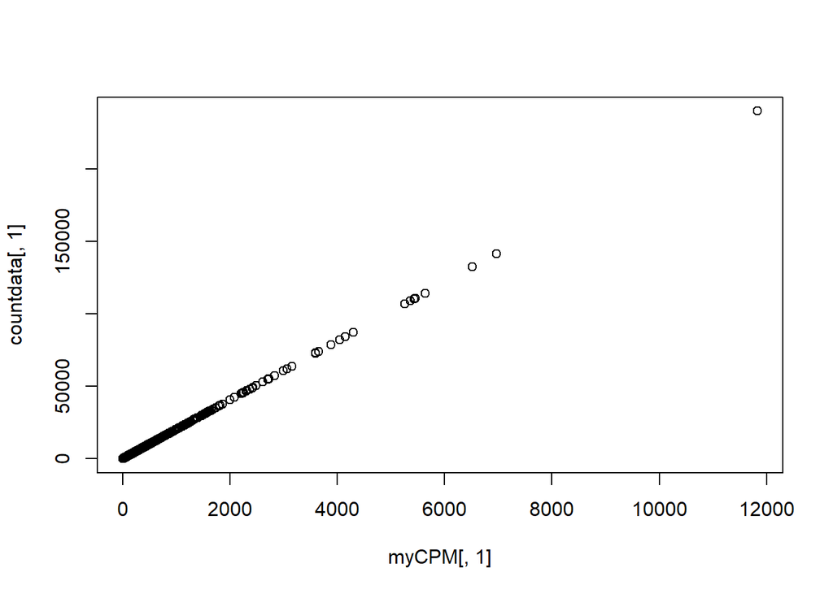

```r
plot(myCPM[,1], countdata[,1])
```

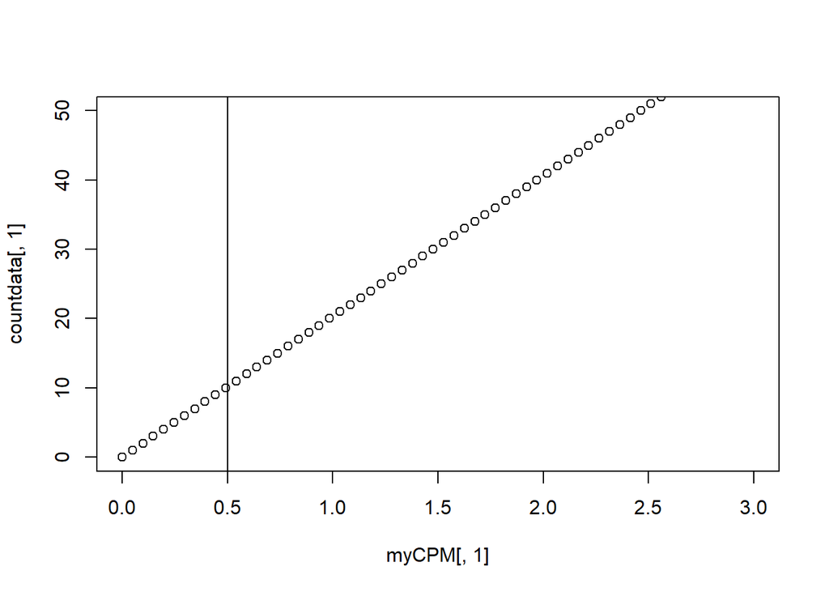

```r
plot(myCPM[,1], countdata[,1], ylim=c(0,50), xlim = c(0,3))
abline(v=0.5)
```

> CONSTRUIMOS UN OBJETO DESEQDATASET

```r
dds <- DESeqDataSetFromMatrix(countData = counts.keep,
                              colData = metadata,
                              design = ~ Status)
dds
```

```
class: DESeqDataSet
dim: 15838 12
metadata(1): version
assays(1): counts
rownames(15838): 497097 20671 ... 100861924 170942
rowData names(0):
colnames(12): SRR1552444.fastq.gz.subread.BAM SRR1552445.fastq.gz.subread.BAM ... SRR1552454.fastq.gz.subread.BAM
  SRR1552455.fastq.gz.subread.BAM
colData names(4): FileName SampleName CellType Status
```

```r
dds <- DESeq(dds)
resultsNames(dds)
```

```
[1] "Intercept"                  "Status_pregnant_vs_lactate" "Status_virgin_vs_lactate"
```

```r
# glimmaMDS(dds)

norm_count <- counts(dds, normalized = TRUE)
```

VER LOS RESULTADOS EN UNA TABLA

```r
res <- results(dds)
head(results(dds), 15)
```

```
log2 fold change (MLE): Status virgin vs lactate
Wald test p-value: Status virgin vs lactate
DataFrame with 15 rows and 6 columns
        baseMean log2FoldChange     lfcSE      stat      pvalue        padj
       <numeric>      <numeric> <numeric> <numeric>   <numeric>   <numeric>
497097  126.5298      -0.150027  2.980570 -0.050335 9.59855e-01 0.986134049
20671    50.5807       0.793623  1.001637  0.792326 4.28171e-01 0.692195804
27395   360.2658      -0.499265  0.365319 -1.366655 1.71733e-01 0.410997359
18777   723.7975      -0.741791  0.167859 -4.419122 9.91028e-06 0.000288491
21399  1000.5864       0.150530  0.179590  0.838184 4.01927e-01 0.667714478
...          ...            ...       ...       ...         ...         ...
76187   118.4116      -3.397858  1.067774  -3.18219 0.001461666  0.01479983
72481    17.3863      -1.395257  0.916061  -1.52310 0.127732643  0.34310351
76982    21.4220      -2.729843  0.780826  -3.49610 0.000472117  0.00638467
17864   253.5347       0.862376  0.578541   1.49060 0.136065260  0.35750919
70675  1091.3354       0.311550  0.201549   1.54578 0.122158544  0.33324767
```

```r
write.table(file = "C:/Users/polo/OneDrive/ZZZ/00GENESPECTRUM/00TALLER/SESION07/result_deseq2.txt", res, sep ="\t")
```

```r
summary(res)
```

```
out of 15838 with nonzero total read count
adjusted p-value < 0.1
LFC > 0 (up)       : 1406, 8.9%
LFC < 0 (down)     : 1712, 11%
outliers [1]       : 2, 0.013%
low counts [2]     : 0, 0%
(mean count < 2)
[1] see 'cooksCutoff' argument of ?results
[2] see 'independentFiltering' argument of ?results
```

```r
res <- res[order(res$padj),]
results <- as.data.frame (res)
write.table(file = "C:/Users/polo/OneDrive/ZZZ/00GENESPECTRUM/00TALLER/SESION07/result_deseq3.txt", res, sep = "\t")
```

Podemos usar la función plotCounts para comparar los recuentos normalizados entre los grupos tratados y de control para nuestros genes superiores. También puede ser útil examinar los recuentos de lectura de un solo gen a través de los grupos

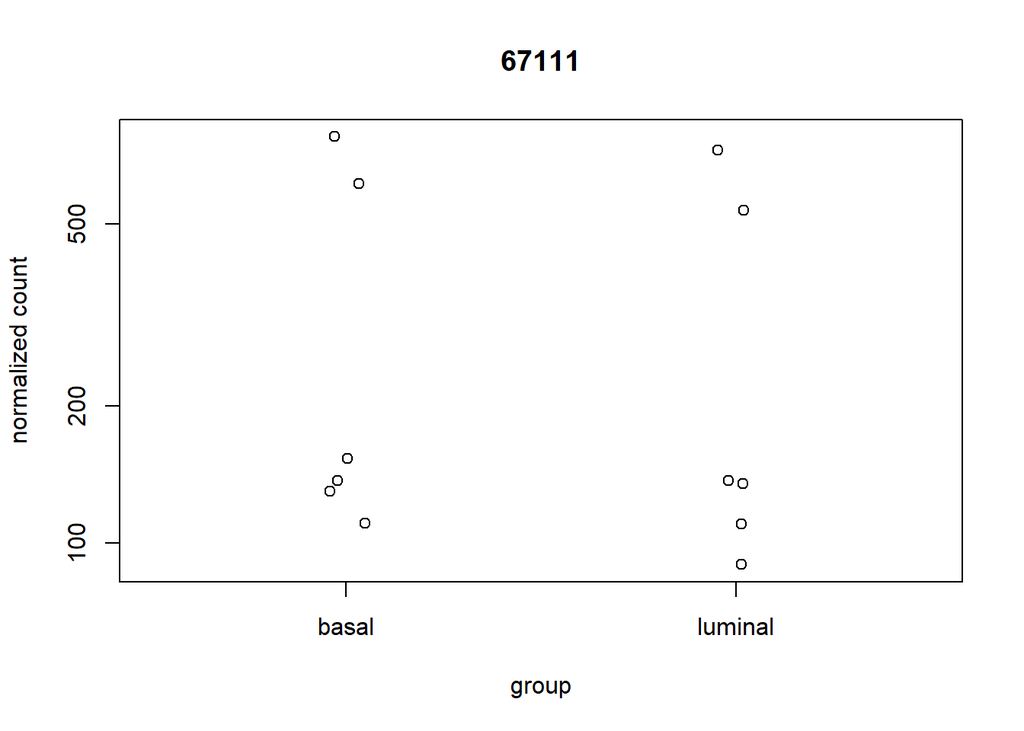

```r
dds$CellType <- as.factor(dds$CellType)
plotCounts(dds, gene="67111", intgroup = "CellType")
```

Para tener una mejor estimación del LFC de genes que: - Son poco abundantes - Tienen alta dispersión Usemos la función lfcShrink de la librería apeglm

```r
# BiocManager::install("apeglm")
library(apeglm)

res_lfc <- lfcShrink(dds, coef = "Status_pregnant_vs_lactate")
res_lfc
```

```
log2 fold change (MAP): Status pregnant vs lactate
Wald test p-value: Status pregnant vs lactate
DataFrame with 15838 rows and 5 columns
           baseMean log2FoldChange     lfcSE      pvalue        padj
          <numeric>      <numeric> <numeric>   <numeric>   <numeric>
497097     126.5298    -0.00787787  0.254223   0.6739414    0.935860
20671       50.5807     0.01994733  0.248092   0.7478671    0.960470
27395      360.2658    -0.10287937  0.226188   0.4080385    0.810832
18777      723.7975    -0.21987279  0.156723   0.0825413    0.395846
21399     1000.5864     0.14713894  0.157357   0.2444324    0.668818
...             ...            ...       ...         ...         ...
100862004   934.255      1.0509653  0.150861 2.49958e-13 1.72102e-10
100042025   621.246      0.0176720  0.137150 8.92659e-01 9.90229e-01
100861837   129.097     -0.0397306  0.236804 6.71997e-01 9.35713e-01
100861924   254.370      0.6835764  0.296977 1.81386e-03 3.25673e-02
170942     2231.320      1.1985125  0.154768 6.88484e-16 5.73833e-13
```

> MA Plot

En DESeq2, la función plotMA muestra los cambios de pliegue de log2 atribuibles a una variable dada a lo largo de la media de recuentos normalizados para todas las muestras en DESeqDataSet.

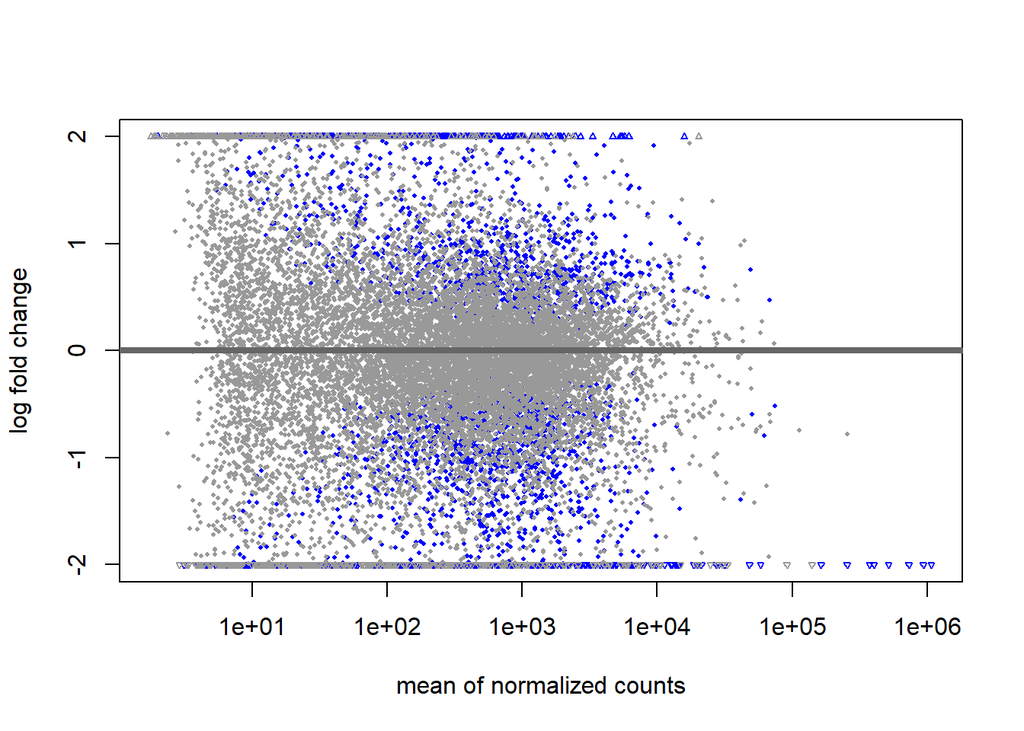

```r
DESeq2::plotMA(res, ylim=c(-2,2))
```

```r
# dds1 <- DESeqDataSetFromMatrix(
#   countData = dds$counts,
#   colData = dds$samples,
#   rowData = dds$genes,
#   design = ~group
# )

# dds <- DESeq(res, quiet = TRUE)
```

> Volcano Plot

Grafico basico

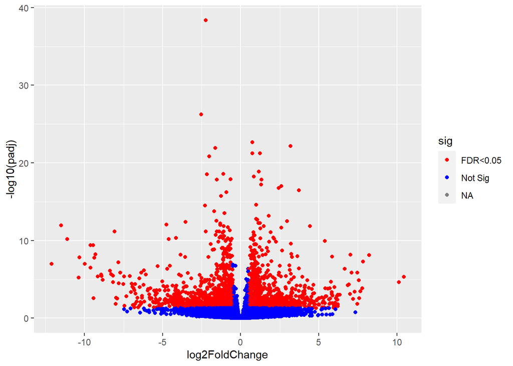

```r
library(dplyr)
res1 = as.data.frame(res)
# añade una nueva columna usando la funcion mutate de dplyr
res1 = mutate(res1, sig=ifelse(res1$padj<0.05, "FDR<0.05", "Not Sig"))
res1[which(abs(res1$log2FoldChange)<0.5), "sig"] <- "Not Sig"

p = ggplot(res1, aes(log2FoldChange, -log10(padj))) +
geom_point(aes(col=sig)) +
scale_color_manual(values = c("red", "blue"))
p
```

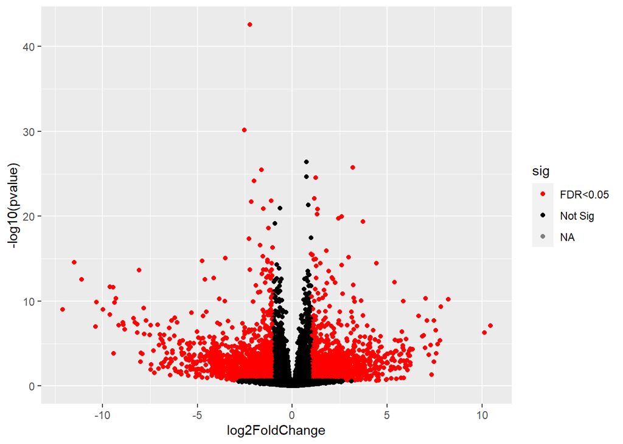

```r
library(dplyr)

resl = as.data.frame(res)
# add a new column using the mutate function in dplyr
res1 = mutate(res1, sig=ifelse(res1$padj<0.5, "FDR<0.05" , "Not Sig"))

res1[which(abs(res1$log2FoldChange)<1 ), 'sig' ] <- "Not Sig"

p = ggplot(res1, aes(log2FoldChange, -log10(pvalue))) +
     geom_point(aes(col=sig)) +
     scale_color_manual(values=c( "red" , "black"))
p
```

```r
# p+geom_text(data=filter(res1, padj<1e-50), aes( label=ALIAS))          # da error
```

Añadimos color a los puntos

Primero necesitamos transformar el datos de conteo sin procesar usando la función vst

```r
vsdata <- vst(dds, blind=FALSE)
```

PCA PLOT ACCORDING TO THE CELL TYPE

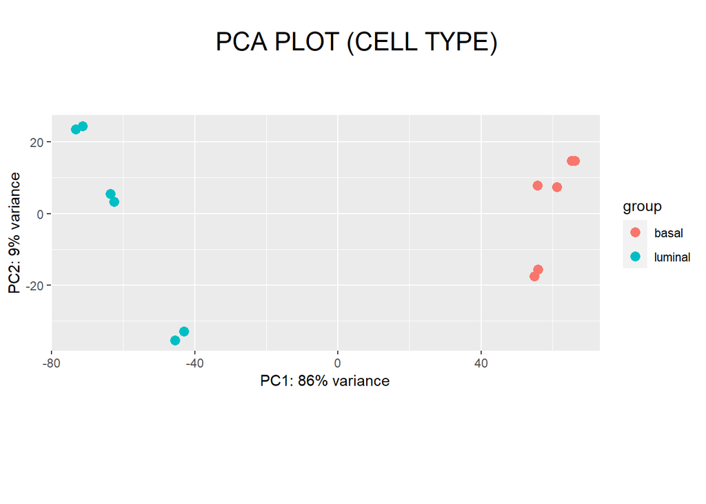

```r
plotPCA(vsdata,
intgroup="CellType")
a = " "
x = "PCA PLOT (CELL TYPE)"
text = paste(a, "\n", x )
grid.text(text, x = 0.5,y= 0.9,
just = "bottom", gp = gpar(fontsize = 18))
```

Usemos la siguiente normalización logarítmica de lascuentas (toma en cuenta el tamaño de la librería)

```r
# BiocManager::install("PCAtools")
library (PCAtools)

rld <- rlog(dds, blind = F)
```

```r
rownames(colData(dds))
```

```
 [1] "SRR1552444.fastq.gz.subread.BAM" "SRR1552445.fastq.gz.subread.BAM" "SRR1552446.fastq.gz.subread.BAM" "SRR1552447.fastq.gz.subread.BAM"
 [5] "SRR1552448.fastq.gz.subread.BAM" "SRR1552449.fastq.gz.subread.BAM" "SRR1552450.fastq.gz.subread.BAM" "SRR1552451.fastq.gz.subread.BAM"
 [9] "SRR1552452.fastq.gz.subread.BAM" "SRR1552453.fastq.gz.subread.BAM" "SRR1552454.fastq.gz.subread.BAM" "SRR1552455.fastq.gz.subread.BAM"
```

```r
rowRanges(dds)
```

```
GRangesList object of length 15838:
$`497097`
GRanges object with 0 ranges and 0 metadata columns:
   seqnames    ranges strand
      <Rle> <IRanges>  <Rle>
  -------
  seqinfo: no sequences

$`20671`
GRanges object with 0 ranges and 0 metadata columns:
   seqnames    ranges strand
      <Rle> <IRanges>  <Rle>
  -------
  seqinfo: no sequences

$`27395`
GRanges object with 0 ranges and 0 metadata columns:
   seqnames    ranges strand
      <Rle> <IRanges>  <Rle>
  -------
  seqinfo: no sequences

...
<15835 more elements>
```

```r
seqinfo(rowRanges(dds))
```

```
Seqinfo object with no sequences
```

```r
assayNames(dds)
```

```
[1] "counts" "mu"     "H"      "cooks"
```

```r
head(assay(dds), 5)
```

```
       SRR1552444.fastq.gz.subread.BAM SRR1552445.fastq.gz.subread.BAM SRR1552446.fastq.gz.subread.BAM SRR1552447.fastq.gz.subread.BAM
497097                               0                               0                               0                               0
20671                               16                              25                              18                               8
27395                              558                             468                             488                             332
18777                              798                             843                             658                             632
21399                             1222                            1138                             979                             819
       SRR1552448.fastq.gz.subread.BAM SRR1552449.fastq.gz.subread.BAM SRR1552450.fastq.gz.subread.BAM SRR1552451.fastq.gz.subread.BAM
497097                               0                               0                             438                             299
20671                                3                              10                             106                             181
27395                              312                             344                             309                             232
18777                              530                             565                             629                             501
21399                              452                             472                            1497                            1353
       SRR1552452.fastq.gz.subread.BAM SRR1552453.fastq.gz.subread.BAM SRR1552454.fastq.gz.subread.BAM SRR1552455.fastq.gz.subread.BAM
497097                              65                             237                             354                             287
20671                               82                             104                              43                              83
27395                              340                             297                             291                             270
18777                              918                             918                             885                             766
21399                             1548                            1217                            1056                             960
```

```r
# Las matriz de abundancia (TPM) puede obtener

head(dds@assays@data$abundance, 5)
```

[output not shown]

Crear un objeto que contenga los datos del PCA

```r
PCA <- pca(assay(rld), scale = T , metadata = colData(rld))
head(PCA$loadings,10)
```

```
                 PC1           PC2           PC3          PC4          PC5           PC6           PC7          PC8          PC9         PC10
497097  0.0104905230  0.0046632588  0.0008299592 -0.002973176 -0.006437724  0.0017035648  0.0003306100 -0.001895259  0.003480839  0.008983732
20671   0.0101449127  0.0005285608  0.0012298424 -0.007358219 -0.002666572  0.0004513226 -0.0114090929  0.012457079 -0.009903557  0.010700402
27395  -0.0100202949  0.0048897963  0.0010682933  0.004497572  0.006797143 -0.0126559173  0.0008981268  0.001539794  0.008340846  0.003969765
18777  -0.0027063988  0.0138837780 -0.0033467896  0.009453775  0.016434018 -0.0040507801 -0.0030842023 -0.007421115  0.004461096  0.001225725
21399   0.0095700205 -0.0023995254 -0.0046924637 -0.009649699  0.003739913 -0.0098547158 -0.0012108918 -0.001870429  0.011144674 -0.008133656
58175  -0.0094004998 -0.0080741069 -0.0020126292  0.004792302  0.006835200 -0.0072269500  0.0075652474  0.002537934 -0.001648123 -0.004844913
108664 -0.0098197879  0.0076027324 -0.0046402301  0.003631190  0.003588035  0.0013004989  0.0014389348  0.001620357  0.001612641  0.000347403
12421   0.0015084609  0.0079610865 -0.0061871223  0.012239058 -0.024340062  0.0047675843  0.0117323216  0.003812631  0.006357279 -0.009551282
319263 -0.0009296509  0.0181193832  0.0006912666  0.003394049 -0.001492921  0.0051851395 -0.0007706509 -0.004780204  0.004496421  0.004889503
59014   0.0047170214 -0.0070507454 -0.0069994517 -0.018585481  0.009338947  0.0023152491 -0.0038679985 -0.003818906  0.011316868 -0.002514868
               PC11        PC12
497097 -0.002029309  0.07164345
20671   0.003896450 -0.07191383
27395   0.006210258 -0.30093259
18777  -0.007085433 -0.22125642
21399   0.010136384  0.02626659
58175   0.001123034 -0.09093703
108664  0.001255431  0.20139735
12421   0.003101030 -0.20420216
319263  0.006170883  0.09319322
59014   0.003162692  0.12021092
```

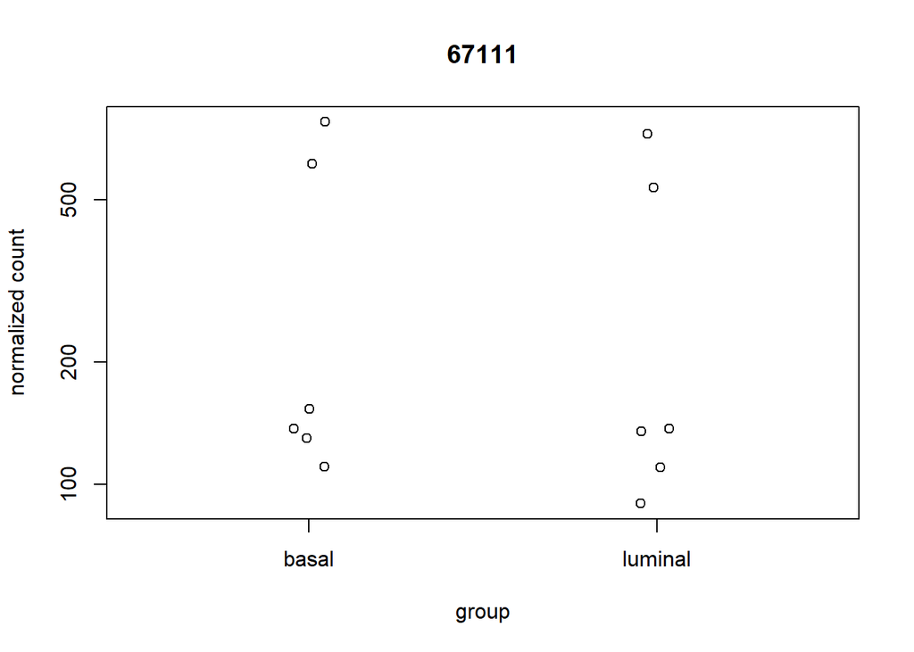

```r
#Anotaciones de genes

dds$CellType <- as.factor(dds$CellType)
plotCounts(dds, gene="67111", intgroup = "CellType")
```

```r
# topGene <- res@rownames[1]
# plotCounts(dds, gene = topGene, lntgroup = c("p53" , "treatnent"))
```

Hacemos un archivo con solo los genes con un valor p ajustado < 0.5

```r
resSig = as.data.frame(subset(res, padj<0.5))
resSig = resSig[order(resSig$log2FoldChange, decreasing=TRUE),]
head(resSig)
```

```
            baseMean log2FoldChange    lfcSE     stat       pvalue         padj
100043899  114.30828      10.441337 1.945615 5.366599 8.023498e-08 4.717489e-06
12945       92.02520      10.130182 2.016176 5.024454 5.048663e-07 2.277796e-05
71874       88.97606       8.215574 1.254588 6.548425 5.814699e-11 7.486306e-09
11839     2027.30192       7.845933 1.259437 6.229715 4.672845e-10 5.068436e-08
22239       51.07904       7.798571 1.695510 4.599543 4.234178e-06 1.438894e-04
622127     160.76726       7.659521 1.752580 4.370425 1.240048e-05 3.512953e-04
```

Glimma es un widget R interactivo para crear gráficos para el análisis de expresiones diferenciales, creado utilizando los marcos Vega y htmlwidgets. Los gráficos creados se pueden incrustar en R Markdown o exportar como documentos HTML independientes:

https://bioconductor.org/packages/release/bioc/vignettes/Glimma/inst/doc/DESeq2.html  
https://bioconductor.org/packages/release/bioc/vignettes/Glimma/inst/doc/limma_edger.html  
https://bioconductor.org/packages/release/bioc/vignettes/Glimma/inst/doc/single_cell_edger.html  
https://bioc.ism.ac.jp/packages/3.7/bioc/vignettes/Glimma/inst/doc/Glimma.pdf

> ANOTACIONES

```r
# BiocManager::install("org.Mm.eg.db")
library(org.Mm.eg.db)
library(AnnotationDbi)
columns(org.Mm.eg.db)
```

```
 [1] "ACCNUM"       "ALIAS"        "ENSEMBL"      "ENSEMBLPROT"  "ENSEMBLTRANS" "ENTREZID"     "ENZYME"       "EVIDENCE"     "EVIDENCEALL"
[10] "GENENAME"     "GENETYPE"     "GO"           "GOALL"        "IPI"          "MGI"          "ONTOLOGY"     "ONTOLOGYALL"  "PATH"
[19] "PFAM"         "PMID"         "PROSITE"      "REFSEQ"       "SYMBOL"       "UNIPROT"
```

Para extraer la información que necesitamos, usaremos una clave o colección de claves para filtrar la base de datos. La siguiente es una lista de claves válidas. La función de tipos de clave se puede utilizar para adquirir esta informacion.

```r
keytypes(org.Mm.eg.db)
```

```
 [1] "ACCNUM"       "ALIAS"        "ENSEMBL"      "ENSEMBLPROT"  "ENSEMBLTRANS" "ENTREZID"     "ENZYME"       "EVIDENCE"     "EVIDENCEALL"
[10] "GENENAME"     "GENETYPE"     "GO"           "GOALL"        "IPI"          "MGI"          "ONTOLOGY"     "ONTOLOGYALL"  "PATH"
[19] "PFAM"         "PMID"         "PROSITE"      "REFSEQ"       "SYMBOL"       "UNIPROT"
```

Si no estamos seguros de qué valores están permitidos para una clave, podemos usar claves para ver qué claves son aceptables.

```r
keys(org.Mm.eg.db, keytype="ENTREZID")[1:10]
```

```
 [1] "11287" "11298" "11302" "11303" "11304" "11305" "11306" "11307" "11308" "11350"
```

Es una buena idea utilizarlo como un control para asegurarse de que todas las claves que desea utilizar son válidos. Podríamos usar %in% en este caso.

```r
my.keys <- c("50916", "110308","12293")
my.keys %in% keys(org.Mm.eg.db, keytype="ENTREZID")
```

```
[1] TRUE TRUE TRUE
```

```r
ann <- select(org.Mm.eg.db,keys=rownames(results), columns=c("ENTREZID","SYMBOL","GENENAME"))
```

La información de la anotación se puede adjuntar al marco de datos de resultados. Además, guarde los DEG que se han anotado en un archivo separado.

```r
results.annotated <- cbind(results, ann)
head(results.annotated, 10)
```

```
            baseMean log2FoldChange      lfcSE       stat       pvalue         padj  ENTREZID    SYMBOL
67111      304.14128     -2.2447901 0.16272690 -13.794831 2.737936e-43 4.335795e-39     67111      Naaa
170459     398.31029     -2.5251074 0.21862411 -11.549995 7.382471e-31 5.845440e-27    170459    Stard4
69237     1554.74991      0.7454039 0.06910990  10.785776 4.018377e-27 2.121167e-23     69237    Gtpbp4
12704       55.71692      3.1809176 0.29867737  10.650012 1.743422e-26 6.902206e-23     12704       Cit
77697      207.19848     -1.6298124 0.15401440 -10.582208 3.603639e-26 1.141344e-22     77697      Mmab
101214    2529.56181      0.7573086 0.07278064  10.405357 2.343767e-25 6.183737e-22    101214     Tra2a
100042069 2215.17261      1.2261642 0.11800593  10.390700 2.733403e-25 6.183737e-22 100042069 Impdh2-ps
66234      704.34660     -2.0178863 0.19592166 -10.299455 7.086140e-25 1.402701e-21     66234     Msmo1
23918      916.79321      1.1570468 0.11761364   9.837693 7.746700e-23 1.363075e-19     23918    Impdh2
56491     1712.67337     -1.1218051 0.11488234  -9.764818 1.593987e-22 2.524237e-19     56491      Vapb
                                                                         GENENAME
67111                                             N-acylethanolamine acid amidase
170459                    StAR-related lipid transfer (START) domain containing 4
69237                                                       GTP binding protein 4
12704                                                                      citron
77697     methylmalonic aciduria (cobalamin deficiency) cblB type homolog (human)
101214                                                        transformer 2 alpha
100042069                       inosine monophosphate dehydrogenase 2, pseudogene
66234                                                 methylsterol monoxygenase 1
23918                                       inosine monophosphate dehydrogenase 2
56491             vesicle-associated membrane protein, associated protein B and C
```

```r
# write.csv (file = "Annotates_DEGs.csv", results.annotated)
```

> ANALISIS FUNCIONAL DE DEGs

La lista de genes expresados diferencialmente es a veces tan larga que su la interpretación se vuelve engorrosa y requiere mucho tiempo. Un procedimiento corriente abajo común es el análisis funcional. Apunta a comprender qué vías o redes de genes diferencian genes expresados están implicados en:

- Seleccion de algunos genes para la validación
- Haz algunos experimentos de seguimiento
- Publicar una tabla enorme con resultados.
- Trate de aprender sobre los genes de la literatura publicada

Método de análisis de un solo gen fundamental en nuestra comprensión de proceso biológico celular. Sin embargo, en el proceso de la enfermedad, no suele ser uno solo sino un conjunto de genes los que intervienen en la clínica manifestación de la enfermedad. Es más relevante estudiar los cambios iniciados por un conjunto de genes que puede alterar dramáticamente varios procesos biológicos y caminos metabólicos celulares. Enfoques comúnmente utilizados para analizar un conjunto de genes por sobre representación (Análisis GO) cálculo de puntaje agregado (GSEA)

> Gene Ontology Enrichment Analysis

Los términos GO proporcionan un vocabulario estandarizado para describir genes y productos geneticos de diferentes especies. Los términos GO nos permiten asignar funcionalidad a los genes.

```r
#BiocManager::install("goseq")
library(goseq)
```

GOseq es un paquete R que proporciona funciones para buscar ontología de genes enriquecidos términos (GO) en nuestros genes expresados diferencialmente. GOseq es un método para realizar análisis de ontología génica (GO) adecuado para RNA-Seq datos, ya que explica el sesgo de longitud del gen en la detección de sobrerrepresentación. El análisis GO de los datos de RNA-seq requiere el uso de muestreo aleatorio para generar una distribución nula adecuada para la pertenencia a la categoría GO y calcular cada categoria significativa de sobre rrepresentación entre los genes DE

GOseq primero necesita cuantificar el sesgo de longitud presente en el conjunto de datos en consideración. Esto se hace calculando una función de ponderación de probabilidad o PWF que se puede considerar como una función que da la probabilidad de que un gen se exprese diferencialmente (DE), en función de su longitud solo. El PWF se calcula ajustando un spline monótono a la serie de datos binarios de diferencial expresión (1=DE, 0=No DE) en función de la longitud del gen. El PWF se utiliza para ponderar la posibilidad de seleccionar cada gen al formar una distriución nula para Membresía en la categoría GO. El hecho de que el PWF se calcule directamente a partir del conjunto de datos en consideración hace que esto enfoque robusto, solo corrigiendo el sesgo de longitud presente en los datos.

> Gene Set Enrichment Analysis (GSEA) **fgsea: enriquecimiento rápido de conjuntos de genes preclasificados análisis (GSEA)**

El enriquecimiento de conjuntos de genes es un enfoque para encontrar conjuntos de genes conectados que están enriquecidos para la expresión diferencial. Análisis estadístico para calcular la importancia del enriquecimiento del conjunto de genes

```r
#BiocManager::install("fgsea")
library(fgsea)
```

El análisis fgsea se realiza mediante: - clasificar todos los genes en el conjunto de datos en función de su correlación con el elgido fenotipo - identificar las posiciones de rango de todos los miembros del conjunto de genes - calculando un puntaje de enriquecimiento (ES) que representa la diferencia entre el clasificaciones observadas y lo que se esperaría asumiendo una clasificación aleatoria distribución.

Después de establecer el ES para cada conjunto de genes en el fenotipo GSEA reiteradamente aleatoriza las etiquetas de muestra y vuelve a probar para enriquecimiento a través de las clases aleatorias.  
Al realizar aleatorizaciones repetidas de etiquetas de clase, el ES para cada El conjunto de genes en las clases verdaderas se puede comparar con el ES distribución de las clases aleatorias.  
Esos conjuntos de genes que superan significativamente la clase aleatoria iterativa las permutaciones se consideran significativas.

La puntuación de enriquecimiento (ES) refleja el grado en que un conjunto de genes es sobrerrepresentado en la parte superior o inferior de una lista clasificada de genes. - ES positivo indica enriquecimiento del conjunto de genes en la parte superior de la lista clasificada. - ES negativo indica enriquecimiento del conjunto de genes en la parte inferior de la lista clasificada.  
Puntaje de enriquecimiento normalizado (NES): explica las diferencias en el conjunto de genes tamaño y en las correlaciones entre conjuntos de genes y el conjunto de datos de expresión. - se puede utilizar para comparar los resultados del análisis entre conjuntos de genes La tasa de descubrimiento falso (FDR) es la probabilidad estimada de que un conjunto de genes con un NES dado representa un hallazgo falso positivo. - Por ejemplo, un FDR del 25 % indica que es probable que el resultado sea válido 3 de 4 veces. El valor p nominal estima la significación estadística del enriquecimiento puntuación para un solo conjunto de genes.

> DAVID

Base de datos para anotación, visualización y descubrimiento integrado - Proporciona un conjunto integral de herramientas de anotación funcional para que los investigadores entender el significado biológico detrás de una gran lista de genes. - Las listas de identificadores de genes o proteínas se anotan y resumen rápidamente según a datos categóricos compartidos para Gene Ontology, dominio de proteínas y bioquímica pertenencia a la ruta.

Para cualquier lista de genes dada, las herramientas de DAVID pueden: - Identificar temas biológicos enriquecidos, particularmente términos GO - Descubra grupos de genes relacionados con funciones enriquecidas - Términos de anotación redundantes de clúster - Visualice genes en mapas de rutas BioCarta y KEGG - Convertir identificadores de genes de un tipo a otro Y muchos más…

https://bioinformatics-core-shared-training.github.io/cruk-summerschool-2018/RNASeq2018/html/06_Gene_set_testing.nb.html https://www.youtube.com/watch?v=KY6SS4vRchY https://www.youtube.com/watch?v=EuCH5mqRylE